# **Machine Learning Interview Questions**

## **Q1 : Model Evaluation of imbalanced datasets**

### **Why should you not use accuracy for model evaluation in an imbalanced dataset?**

**Answer:**

Accuracy is not a good metric for evaluating models on imbalanced datasets. In a dataset where 90% of the data belongs to class 0 and 10% belongs to class 1, a model that predicts everything as class 0 would still have 90% accuracy, despite completely failing to identify the minority class (class 1). This leads to **misleading results** because accuracy doesn’t consider the distribution of classes.

**Accuracy Formula**:

```
Accuracy = (True Positives + True Negatives) / (Total Samples)
```

Where:

- **True Positives (TP)**: Correct predictions for the positive class.
- **True Negatives (TN)**: Correct predictions for the negative class.

In imbalanced datasets, this formula often gives a high value, even if the model fails to correctly identify the minority class.

Instead, other metrics like **Precision, Recall, F1-Score, and AUC-ROC** are more informative in evaluating performance, particularly for the minority class.

- **Precision**: Measures how many of the predicted positive cases are actually positive.
- **Recall**: Measures how many of the actual positive cases were predicted correctly.
- **F1-Score**: Harmonic mean of Precision and Recall, balancing both metrics.
- **AUC-ROC**: Evaluates how well the model can distinguish between the two classes by plotting True Positive Rate (Recall) against False Positive Rate.

**Example response for an interview**:  
*"In an imbalanced classification problem, accuracy can give an illusion of high performance when the model is just predicting the majority class. Instead, metrics like Precision, Recall, and F1-Score are more effective in evaluating performance, especially in identifying the minority class. AUC-ROC can also help by showing how well the model discriminates between classes."*

**Python Implementation Example:**

```
from sklearn.metrics import accuracy_score, precision_score, recall_score, f1_score

# Example true and predicted values
y_true = [0, 0, 0, 0, 1, 1, 1, 1, 1, 1]
y_pred = [0, 0, 0, 0, 0, 0, 1, 1, 1, 1]

# Calculate accuracy
accuracy = accuracy_score(y_true, y_pred)
precision = precision_score(y_true, y_pred)
recall = recall_score(y_true, y_pred)
f1 = f1_score(y_true, y_pred)

print(f"Accuracy: {accuracy}")
print(f"Precision: {precision}")
print(f"Recall: {recall}")
print(f"F1 Score: {f1}")
```

In the above example, despite the **accuracy** being decent, metrics like **precision**, **recall**, and **F1-score** will provide a better picture for imbalanced datasets.

### **Explain oversampling and how it can help with imbalanced data.**

**Answer:**

**Oversampling** is a technique used to handle imbalanced datasets by increasing the number of instances in the minority class. This is done by **duplicating** samples or creating synthetic samples. Oversampling ensures that the model is trained on a more balanced dataset, preventing it from being biased towards the majority class.

**Popular Oversampling Techniques:**

1. **Random Oversampling**: Randomly duplicates samples from the minority class until the classes are balanced. While simple, it can lead to **overfitting** because the model may memorize these duplicated instances.
2. **SMOTE (Synthetic Minority Over-sampling Technique)**: A more advanced technique where new synthetic samples are created by interpolating between existing minority class samples.

**Example response for an interview**:  
*"Oversampling helps in balancing the data by either duplicating or synthesizing more minority class samples, allowing the model to pay more attention to the minority class. Techniques like SMOTE are widely used to generate synthetic data points for the minority class, thereby improving the model's ability to generalize."*

**Formula** (for SMOTE synthetic samples creation):

```
New Sample = Sample_min + λ * (Sample_nearest - Sample_min)
```

Where:

- `Sample_min`: A sample from the minority class.
- `Sample_nearest`: The nearest neighbor of `Sample_min`.
- `λ`: A random number between 0 and 1.

**Python Implementation (using SMOTE):**

```
from sklearn.datasets import make_classification
from imblearn.over_sampling import SMOTE
import matplotlib.pyplot as plt

# Create an imbalanced dataset
X, y = make_classification(n_samples=1000, n_features=2, n_informative=2,
                           n_redundant=0, n_clusters_per_class=1,
                           weights=[0.9], flip_y=0, random_state=42)

# Apply SMOTE
sm = SMOTE(random_state=42)
X_resampled, y_resampled = sm.fit_resample(X, y)

# Plot original vs resampled data
fig, axs = plt.subplots(1, 2, figsize=(10, 5))

axs[0].scatter(X[:, 0], X[:, 1], c=y)
axs[0].set_title('Original Data')

axs[1].scatter(X_resampled[:, 0], X_resampled[:, 1], c=y_resampled)
axs[1].set_title('Resampled Data (SMOTE)')

plt.show()
```

### **Explain undersampling and its benefits and drawbacks.**

**Answer:**

**Undersampling** is the opposite of oversampling. It reduces the size of the majority class to balance the dataset. By removing some of the majority class instances, we can make the dataset more balanced and avoid biasing the model towards the majority class.

**Benefits:**

- It is computationally less expensive since the dataset becomes smaller.
- Can work well when there’s a lot of redundancy in the majority class.

**Drawbacks:**

- By removing data, you risk losing important information from the majority class.
- This can lead to **underfitting**, where the model doesn't learn enough because important patterns in the majority class may be discarded.

**Example response for an interview**:  
*"Undersampling is useful when we have large datasets, as it reduces the training data size by removing instances from the majority class. While it balances the dataset, it comes with the risk of losing valuable data from the majority class, potentially underfitting the model."*

**Example Formula** for undersampling:  
If we have 1000 samples in the majority class and 100 in the minority class, we randomly select 100 samples from the majority class to create a balanced dataset.

**Python Implementation Example:**

```
from imblearn.under_sampling import RandomUnderSampler

# Original dataset (same as above)
X, y = make_classification(n_samples=1000, n_features=2, n_informative=2,
                           n_redundant=0, n_clusters_per_class=1,
                           weights=[0.9], flip_y=0, random_state=42)

# Apply Random Undersampling
rus = RandomUnderSampler(random_state=42)
X_resampled, y_resampled = rus.fit_resample(X, y)

# Plot original vs resampled data
fig, axs = plt.subplots(1, 2, figsize=(10, 5))

axs[0].scatter(X[:, 0], X[:, 1], c=y)
axs[0].set_title('Original Data')

axs[1].scatter(X_resampled[:, 0], X_resampled[:, 1], c=y_resampled)
axs[1].set_title('Resampled Data (Undersampling)')

plt.show()
```

### **What is SMOTE, and how does it work?**

**Answer:**

**SMOTE (Synthetic Minority Over-sampling Technique)** is an oversampling technique that creates synthetic examples rather than simply duplicating minority class samples.

**How it works:**

- For each minority class sample, SMOTE selects its **k-nearest neighbors**.
- It then creates a new synthetic sample by randomly choosing one of the neighbors and generating a point along the line connecting the two samples.
- This way, it generates new instances that are not mere copies but fall in between existing minority class examples.

**Benefits:**

- **Reduces overfitting**: Since it generates new synthetic samples rather than duplicating data, the model doesn’t memorize the data.
- **Balances the data**: Improves model performance by making the data distribution more balanced.

**Example response for an interview**:  
*"SMOTE is a technique that generates synthetic samples for the minority class by interpolating between existing samples and their nearest neighbors. This helps the model to generalize better and avoid overfitting, which can occur in simple random oversampling methods."*

```
New Sample = Sample_min + λ * (Sample_nearest - Sample_min)
```

### **How can you alter the cost function to address imbalanced data?**

**Answer:**

In **imbalanced classification problems**, we can **alter the cost function** of the model to penalize misclassifying the minority class more than the majority class. This approach assigns **higher weights** to the minority class during training, which forces the model to focus more on correctly predicting minority class samples.

**Examples of altering cost functions:**

1. **Weighted Loss Function**: In algorithms like Logistic Regression or SVM, we can add class weights to the loss function. This means that the model will incur a larger penalty for misclassifying minority class samples, forcing it to pay more attention to those samples.
   - In Scikit-Learn, you can use `class_weight='balanced'` in many classifiers (like Logistic Regression, SVM, etc.) to automatically adjust the weights inversely proportional to class frequencies.
2. **Focal Loss** (used in deep learning): A variant of cross-entropy loss that adds a modulating term to focus learning more on hard-to-classify examples (usually from the minority class).

**Mathematical Intuition** (for weighted loss): Let `W_0` and `W_1` represent the weights assigned to class 0 and class 1, respectively. The loss function can be modified as:

```
L = W_0 * L_0 + W_1 * L_1
```

Where:

- `L_0` and `L_1` represent the individual loss for class 0 and class 1.
- `W_0` and `W_1` are inversely proportional to the class frequencies.

**Example response for an interview**:  
*"By altering the cost function, we can assign higher weights to the minority class, ensuring the model pays more attention to misclassifications in that class. This technique works well in logistic regression, SVMs, and even deep learning models, using weighted loss or focal loss."*

**Python Implementation Example:**

```
from sklearn.ensemble import RandomForestClassifier
from sklearn.model_selection import train_test_split
from sklearn.metrics import classification_report

# Create dataset
X, y = make_classification(n_samples=1000, n_features=20, n_informative=2,
                           n_redundant=10, weights=[0.9], flip_y=0, random_state=42)

# Train-test split
X_train, X_test, y_train, y_test = train_test_split(X, y, test_size=0.2, random_state=42)

# Apply weighted classifier
clf = RandomForestClassifier(class_weight='balanced', random_state=42)
clf.fit(X_train, y_train)

# Predictions
y_pred = clf.predict(X_test)

# Classification report
print(classification_report(y_test, y_pred))
```

In this implementation, the `class_weight='balanced'` parameter automatically assigns weights to classes inversely proportional to their frequencies in the data.

### **Summary of Formulas and Python Examples**

1. **Accuracy Formula**: **Why accuracy is a poor metric**: It can mislead you into thinking your model is performing well even if it's just predicting the majority class.
   - Formula: `Accuracy = (TP + TN) / (Total Samples)`

   Python: `accuracy_score`
2. **Oversampling Formula (SMOTE)**: Duplicates or generates synthetic samples for the minority class.

   ```
   New Sample = Sample_min + λ * (Sample_nearest - Sample_min)
   ```

   Python: `SMOTE`
3. **Undersampling Formula**: Reduces the number of majority class instances to balance the dataset.

   Python: `class_weight='balanced'`
5. **Altering cost function**: Assign higher weights to the minority class during training to make the model focus on correctly predicting minority class examples.

Each technique has its advantages and drawbacks, and in practice, combining these methods (like oversampling with altering the cost function) can often yield the best results.

## **Q2 : Showcase your understanding of K-Means and the Elbow Method**

1. **How to choose the optimal value of K?**
2. **What is the Elbow method?**
3. **What is WCSS (Within-Cluster Sum of Squares)?**
4. **Explain Euclidean distance and its related formulas.**
5. **Python implementation of the Elbow method for determining the optimal K.**

### **How to Choose the Optimal Value of K?**

**Answer:** In clustering (specifically in K-Means), the value of `K` represents the number of clusters. The selection of the optimal number of clusters is crucial because it directly impacts the model's performance. If you choose a very small `K`, clusters might be too broad, missing finer groups within the data. On the other hand, a very large `K` may lead to overfitting by creating too many small clusters.

The **Elbow Method** is the most commonly used technique to choose the optimal value of `K`. This method helps to find the "elbow point" where adding more clusters (increasing `K`) doesn’t significantly improve the model.

### **What is the Elbow Method?**

**Answer:** The **Elbow Method** is used to select the optimal number of clusters by fitting the model with a range of values for `K` and calculating the **Within-Cluster Sum of Squares (WCSS)** for each `K`.

- As `K` increases, the **WCSS** decreases, but there comes a point (elbow point) where the rate of decrease sharply slows down. This is where the additional clusters stop improving the model much, and the optimal `K` is often chosen at this point.

### **What is WCSS (Within-Cluster Sum of Squares)?**

**Answer:** **WCSS** is a measure of the variance within each cluster. It helps to quantify the compactness of the clusters, which is minimized during the K-means clustering process.

#### **WCSS Formula**:

```
WCSS = Σ Σ || x_i - μ_j ||²
```

Where:

- `x_i`: Each data point in the cluster.
- `μ_j`: The centroid of the cluster.
- `|| x_i - μ_j ||²`: The Euclidean distance between the data point `x_i` and the centroid `μ_j`.

### **What is Euclidean Distance?**

**Answer:** The **Euclidean Distance** is the straight-line distance between two points in Euclidean space. It’s the most common distance metric used in K-Means clustering to calculate the distance between points and centroids.

#### **Euclidean Distance Formula**:

In 2D space, the Euclidean distance between two points ( P(x_1, y_1) ) and ( Q(x_2, y_2) ) is:

```
Distance = √((x_2 - x_1)² + (y_2 - y_1)²)
```

In n-dimensional space:

```
Distance = √(Σ (x_i - y_i)²)  # Summing over all dimensions i
```

Where:

- `x_i` and `y_i` are the coordinates of the two points.

### **Python Implementation of the Elbow Method**

Now, let's implement the Elbow Method in Python using `scikit-learn` to choose the optimal `K` for K-Means clustering.

```
import numpy as np
import matplotlib.pyplot as plt
from sklearn.cluster import KMeans
from sklearn.datasets import make_blobs

# Create a dataset with random data
X, y = make_blobs(n_samples=300, centers=4, random_state=42, cluster_std=0.6)

# Plot the data points
plt.scatter(X[:, 0], X[:, 1], s=50, c='blue', marker='o')
plt.title('Generated Data')
plt.show()

# Calculate WCSS for different values of K
wcss = []
K_values = range(1, 11)

for k in K_values:
    kmeans = KMeans(n_clusters=k, random_state=42)
    kmeans.fit(X)
    wcss.append(kmeans.inertia_)  # Inertia is WCSS in KMeans

# Plot the Elbow Method Graph
plt.plot(K_values, wcss, marker='o')
plt.title('Elbow Method for Optimal K')
plt.xlabel('Number of clusters (K)')
plt.ylabel('WCSS (Within-Cluster Sum of Squares)')
plt.show()
```

#### **Explanation of the Code**:

- We generate random data using `make_blobs`.
- For a range of values of `K` (from 1 to 10), we calculate the **WCSS** using the `inertia_` attribute of the K-Means model.
- We plot the **Elbow Method** curve, where the "elbow point" will help us choose the optimal `K`.

### **Summary of Formulas**

1. **WCSS Formula**:

```
WCSS = Σ Σ || x_i - μ_j ||²
```

2. **Euclidean Distance Formula** (2D):

```
Distance = √((x_2 - x_1)² + (y_2 - y_1)²)
```

3. **Euclidean Distance Formula** (n-dimensional):

```
Distance = √(Σ (x_i - y_i)²)
```

### **Conclusion**

- **Elbow Method** helps determine the optimal `K` in K-Means by plotting **WCSS** against `K`.
- **WCSS** decreases with increasing `K`, and the **Euclidean Distance** is used to compute the distance between points and centroids.
- The "elbow point" in the curve is the ideal value for `K`, where adding more clusters stops benefiting the model much.

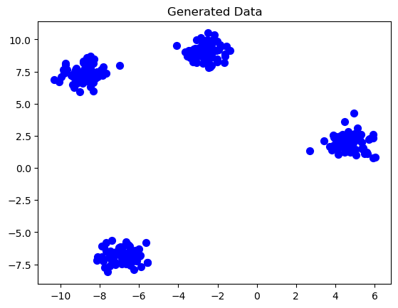

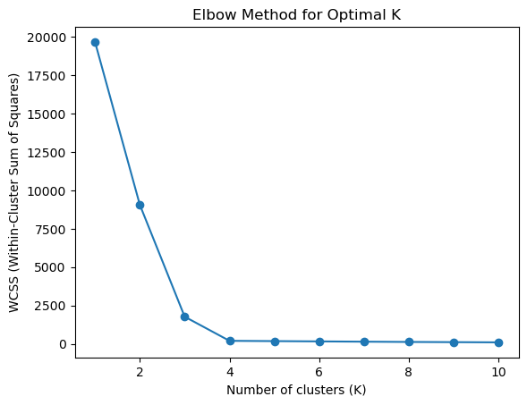

```python
import numpy as np
import matplotlib.pyplot as plt
from sklearn.cluster import KMeans
from sklearn.datasets import make_blobs

# Create a dataset with random data
X, y = make_blobs(n_samples=300, centers=4, random_state=42, cluster_std=0.6)

# Plot the data points
plt.scatter(X[:, 0], X[:, 1], s=50, c='blue', marker='o')
plt.title('Generated Data')
plt.show()

# Calculate WCSS for different values of K
wcss = []
K_values = range(1, 11)

for k in K_values:
    kmeans = KMeans(n_clusters=k, random_state=42)
    kmeans.fit(X)
    wcss.append(kmeans.inertia_)  # Inertia is WCSS in KMeans

# Plot the Elbow Method Graph
plt.plot(K_values, wcss, marker='o')
plt.title('Elbow Method for Optimal K')
plt.xlabel('Number of clusters (K)')
plt.ylabel('WCSS (Within-Cluster Sum of Squares)')
plt.show()
```

## **Q3 : K-Means vs K-Means++**

**K-Means** and **K-Means++** are both popular clustering algorithms, but they differ mainly in how they initialize the cluster centroids. Here's a detailed explanation of both:

### **1. K-Means Algorithm**

**K-Means** is one of the simplest and most widely used clustering algorithms. It partitions the data into `K` clusters, where each data point belongs to the cluster with the nearest mean (centroid). The goal is to minimize the **WCSS (Within-Cluster Sum of Squares)**.

#### **K-Means Algorithm Steps:**

1. **Random Initialization**: Randomly initialize `K` centroids.
2. **Assign Data Points**: Assign each data point to the nearest centroid based on Euclidean distance.
3. **Update Centroids**: For each cluster, compute the new centroid by taking the mean of the points assigned to that cluster.
4. **Repeat**: Repeat steps 2 and 3 until the centroids no longer change or the maximum number of iterations is reached.

#### **Problems with K-Means:**

- **Random Initialization**: K-Means randomly initializes the centroids, which can lead to poor clustering if the centroids are poorly initialized. Sometimes the algorithm gets stuck in local minima and provides suboptimal clusters.

### **2. K-Means++ Algorithm**

**K-Means++** is an improved version of K-Means that addresses the issue of random initialization by using a smarter initialization strategy. The goal of K-Means++ is to spread out the initial centroids, leading to better clustering performance and faster convergence.

#### **K-Means++ Algorithm Steps:**

1. **First Centroid**: Randomly choose the first centroid from the data points.
2. **Distance-based Selection**:
   - For each data point `x`, compute its distance `D(x)` from the nearest already chosen centroid.
   - The probability of choosing a new centroid is proportional to `D(x)²`. This ensures that points farther from existing centroids have a higher probability of being chosen.
3. **Repeat**: Repeat step 2 until `K` centroids have been chosen.
4. **Standard K-Means**: Run the standard K-Means algorithm with these initialized centroids.

### **3. K-Means vs K-Means++: Key Differences**

| Feature | **K-Means** | **K-Means++** |
| --- | --- | --- |
| **Centroid Initialization** | Random initialization of centroids | Smarter initialization that spreads out centroids |
| **Performance** | Can lead to suboptimal clustering and slow convergence | Faster convergence and better clustering |
| **Convergence** | May converge to local minima (poor results) | Reduces the chances of local minima |
| **Computation Time** | May require more iterations to converge | Requires fewer iterations, but slightly more time for initialization |
| **Use Cases** | Useful when computational simplicity is more important | Useful when accuracy and faster convergence are required |

### **4. Why K-Means++ is Better?**

- **Better Initialization**: K-Means++ improves the initial centroids by ensuring they are spread out. This reduces the risk of poor clusters and the chances of getting stuck in local minima.
- **Faster Convergence**: By choosing better starting points, K-Means++ often converges faster, requiring fewer iterations.
- **More Stable Results**: K-Means++ typically produces more stable clusters, especially when dealing with non-globular data.

### **5. Mathematical Explanation**

#### **K-Means Initialization**:

- In the original K-Means algorithm, centroids are initialized randomly, which can lead to poor clusters. The formula for assigning points to clusters is based on minimizing the Euclidean distance between data points `x` and centroids `μ_j`:

```
WCSS = Σ Σ || x_i - μ_j ||²
```

#### **K-Means++ Initialization**:

- K-Means++ initializes centroids based on distance. After selecting the first random centroid, subsequent centroids are chosen with a probability proportional to the square of the distance from the closest centroid:

```
P(x) ∝ D(x)²
```

Where:

- `D(x)` is the distance of a point `x` to the nearest chosen centroid.

### **6. Python Implementation of K-Means++**

Here's a simple implementation of K-Means++ using `scikit-learn`:

```
import numpy as np
import matplotlib.pyplot as plt
from sklearn.cluster import KMeans
from sklearn.datasets import make_blobs

# Create a dataset with random data
X, y = make_blobs(n_samples=300, centers=4, random_state=42, cluster_std=0.6)

# K-Means without K-Means++
kmeans = KMeans(n_clusters=4, init='random', random_state=42)
kmeans.fit(X)
y_kmeans = kmeans.predict(X)

# K-Means with K-Means++
kmeans_pp = KMeans(n_clusters=4, init='k-means++', random_state=42)
kmeans_pp.fit(X)
y_kmeans_pp = kmeans_pp.predict(X)

# Plot the results
fig, (ax1, ax2) = plt.subplots(1, 2, figsize=(12, 6))

ax1.scatter(X[:, 0], X[:, 1], c=y_kmeans, cmap='viridis')
ax1.set_title('K-Means (Random Initialization)')

ax2.scatter(X[:, 0], X[:, 1], c=y_kmeans_pp, cmap='viridis')
ax2.set_title('K-Means++ (Smart Initialization)')

plt.show()
```

#### **Explanation:**

- We use `init='random'` for the traditional K-Means and `init='k-means++'` for K-Means++.
- The plot shows the differences between random initialization and K-Means++ initialization.

### **7. When to Use K-Means++?**

- **Data with well-separated clusters**: K-Means++ is especially useful when the data has distinct clusters, as it helps in getting a good initialization, reducing the number of iterations required.
- **Large datasets**: On larger datasets, poor initialization can lead to significantly worse performance. K-Means++ mitigates this by ensuring better centroids from the start.

### **Conclusion**

- **K-Means** uses random initialization, which can sometimes result in suboptimal clusters and slower convergence.
- **K-Means++** uses a smarter initialization technique that spreads out centroids more effectively, leading to faster convergence and better clustering results.

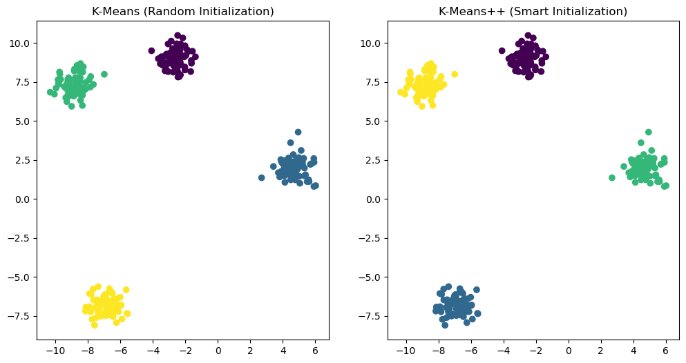

```python
import numpy as np
import matplotlib.pyplot as plt
from sklearn.cluster import KMeans
from sklearn.datasets import make_blobs

# Create a dataset with random data
X, y = make_blobs(n_samples=300, centers=4, random_state=42, cluster_std=0.6)

# K-Means without K-Means++
kmeans = KMeans(n_clusters=4, init='random', random_state=42)
kmeans.fit(X)
y_kmeans = kmeans.predict(X)

# K-Means with K-Means++
kmeans_pp = KMeans(n_clusters=4, init='k-means++', random_state=42)
kmeans_pp.fit(X)
y_kmeans_pp = kmeans_pp.predict(X)

# Plot the results
fig, (ax1, ax2) = plt.subplots(1, 2, figsize=(12, 6))

ax1.scatter(X[:, 0], X[:, 1], c=y_kmeans, cmap='viridis')
ax1.set_title('K-Means (Random Initialization)')

ax2.scatter(X[:, 0], X[:, 1], c=y_kmeans_pp, cmap='viridis')
ax2.set_title('K-Means++ (Smart Initialization)')

plt.show()
```

## **Q4 : What is motivation to use the Random Forest algorithm in machine learning**

The motivation to use the Random Forest algorithm in machine learning stems from several key advantages and goals it addresses in predictive modeling and classification tasks:

### 1. **Accuracy**

Random Forest is known for providing high accuracy in many scenarios, outperforming other algorithms on complex datasets due to its ability to handle large data sets with higher dimensionality. It can produce a highly accurate classifier by combining multiple decision trees to reduce the model’s variance.

### 2. **Robustness**

Random Forest is less prone to overfitting than other algorithms. By averaging or combining the results of different trees, it balances out biases and errors. Each tree in the forest is built from a sample drawn with replacement (bootstrap sample) from the training set, allowing the model to maintain robustness even with noisy data.

### 3. **Handling Non-linear Data**

Unlike algorithms that assume a linear relationship, Random Forest can handle non-linearity effectively, using its hierarchical structure to fit complex datasets.

### 4. **Variable Importance**

One of the useful by-products of Random Forest is the straightforward ranking of features according to their importance in making accurate predictions. This is particularly beneficial in feature selection where understanding which features are contributing most to the prediction can be crucial.

### 5. **Minimal Preprocessing**

Random Forest requires little data preprocessing from the user, for example, it does not require normalization of data. It can handle both numerical and categorical data and can model binary, continuous, or categorical outcomes.

### 6. **Flexibility**

It can be used for both classification and regression tasks. For classification, it predicts the class with the most votes from individual trees, whereas for regression, it averages the outputs from individual trees.

### 7. **Ease of Use**

Random Forest models are relatively easy to tune and do not require much tweaking of parameters to get a decent model. Parameters like the number of trees and maximum depth are straightforward and do not require the understanding of the learning rate or regularization terms.

### 8. **Parallelism**

Each tree in the Random Forest is built independently, which allows the training process to be easily parallelized. This is a significant advantage when dealing with large datasets and computing systems capable of parallel processing.

### 9. **Handling Missing Values**

Random Forest can handle missing values. When there is a missing value in a variable, the algorithm will split the data into two parts: one where the data is missing and one where the data is not missing. This feature makes it versatile and powerful when dealing with real-world data that often has missing values.

### 10. **Out-of-Bag Error Estimation**

Random Forest provides an internal validation mechanism through the out-of-bag (OOB) error estimate. Each tree is trained using about two-thirds of the available data. The remaining one-third, not seen by the tree (called the OOB data), can be used to evaluate its performance. This method is an efficient means of cross-validation and provides a good estimate of model accuracy without the need for a separate test set.

### Conclusion

The motivation to use Random Forest is driven by its robustness, accuracy, and ease of use, making it a popular choice for many predictive modeling tasks. Its ability to perform well on both simple and complex data structures without extensive data preprocessing or tuning makes it a versatile tool in the machine learning toolbox.

Below is a simple Python implementation of the **Random Forest** algorithm using `sklearn` for a binary classification problem. I'll also include the necessary steps for loading the dataset, training the Random Forest model, and evaluating its performance.

### Sample Python Implementation of Random Forest

```
# Importing necessary libraries
import numpy as np
import pandas as pd
from sklearn.datasets import load_breast_cancer
from sklearn.model_selection import train_test_split
from sklearn.ensemble import RandomForestClassifier
from sklearn.metrics import accuracy_score, classification_report, confusion_matrix

# Load dataset - Using the breast cancer dataset from sklearn
data = load_breast_cancer()
X = pd.DataFrame(data.data, columns=data.feature_names)
y = pd.Series(data.target)

# Split the dataset into training and testing sets (80% train, 20% test)
X_train, X_test, y_train, y_test = train_test_split(X, y, test_size=0.2, random_state=42)

# Initialize the Random Forest Classifier
rf_model = RandomForestClassifier(n_estimators=100, random_state=42)

# Train the model on the training data
rf_model.fit(X_train, y_train)

# Make predictions on the test data
y_pred = rf_model.predict(X_test)

# Evaluate the model's performance
accuracy = accuracy_score(y_test, y_pred)
conf_matrix = confusion_matrix(y_test, y_pred)
class_report = classification_report(y_test, y_pred)

# Print the evaluation results
print(f"Accuracy: {accuracy * 100:.2f}%")
print("Confusion Matrix:")
print(conf_matrix)
print("Classification Report:")
print(class_report)
```

### Explanation:

1. **Dataset**: I used the breast cancer dataset from `sklearn.datasets`. It is a binary classification problem where the target labels represent whether a tumor is benign (0) or malignant (1).
2. **Splitting Data**: The dataset is split into 80% training data and 20% testing data using `train_test_split`.
3. **Random Forest Classifier**: We initialize the `RandomForestClassifier` with 100 decision trees (`n_estimators=100`). You can increase the number of trees for better performance at the cost of computation time.
4. **Training**: The classifier is trained using the `fit` method on the training data.
5. **Prediction**: After training, predictions are made on the test set using the `predict` method.
6. **Evaluation**: We compute the accuracy using `accuracy_score`, display the confusion matrix with `confusion_matrix`, and generate a detailed classification report using `classification_report`.

### Output Example:

[output not shown]

### Key Points:

- **n_estimators**: This is the number of trees in the forest. In this case, we set it to 100. You can experiment with different values for better accuracy.
- **random_state**: This ensures that the split and the model's results can be reproduced.
- **accuracy_score**: This metric gives the percentage of correct predictions.

By using Random Forest, we can benefit from a robust classification model that handles missing data, performs well on unbalanced data, and provides insights into feature importance as well.

## **Q5 : How to detect outliers**

### 1. **Z-Score (Standard Score)**

The Z-score method calculates how many standard deviations a data point is from the mean. Outliers are usually considered those points where the absolute value of the Z-score is greater than a threshold (typically 3 or -3).

**Formula for Z-Score**:

```
Z = (X - μ) / σ
```

Where:

- `X` = data point
- `μ` = mean of the data
- `σ` = standard deviation of the data

**Python Example**:

```
import numpy as np

# Sample data
data = np.array([10, 12, 14, 15, 100, 12, 11, 12, 13, 15])

# Calculate mean and standard deviation
mean = np.mean(data)
std_dev = np.std(data)

# Calculate Z-scores
z_scores = [(x - mean) / std_dev for x in data]

# Identify outliers (those beyond 3 standard deviations)
outliers = np.where(np.abs(z_scores) > 3)
print("Outliers: ", data[outliers])
```

### 2. **IQR (Interquartile Range)**

The interquartile range is a measure of statistical dispersion and can be used to detect outliers. Outliers are points that fall below the lower bound (`Q1 - 1.5*IQR`) or above the upper bound (`Q3 + 1.5*IQR`).

**Formula for IQR**:

```
IQR = Q3 - Q1
Lower Bound = Q1 - 1.5 * IQR
Upper Bound = Q3 + 1.5 * IQR
```

Where:

- `Q1` = 25th percentile (first quartile)
- `Q3` = 75th percentile (third quartile)

**Python Example**:

```
import numpy as np
import pandas as pd

# Sample data
data = np.array([10, 12, 14, 15, 100, 12, 11, 12, 13, 15])

# Calculate Q1 (25th percentile) and Q3 (75th percentile)
Q1 = np.percentile(data, 25)
Q3 = np.percentile(data, 75)

# Calculate IQR
IQR = Q3 - Q1

# Define bounds for outliers
lower_bound = Q1 - 1.5 * IQR
upper_bound = Q3 + 1.5 * IQR

# Identify outliers
outliers = data[(data < lower_bound) | (data > upper_bound)]
print("Outliers: ", outliers)
```

### 3. **Boxplot Method**

Boxplots visualize the distribution of the data and provide an easy way to spot outliers. Data points that are beyond the whiskers of the boxplot are considered potential outliers.

**Python Example**:

```
import matplotlib.pyplot as plt

# Sample data
data = [10, 12, 14, 15, 100, 12, 11, 12, 13, 15]

# Create a boxplot
plt.boxplot(data)
plt.show()
```

### 4. **DBSCAN (Density-Based Spatial Clustering of Applications with Noise)**

DBSCAN is an unsupervised machine learning algorithm that groups data points based on density. Points that are not part of any cluster (or noise points) are considered outliers.

**Python Example**:

```
from sklearn.cluster import DBSCAN
import numpy as np

# Sample 2D data
data = np.array([[1, 2], [2, 2], [2, 3], [8, 7], [8, 8], [25, 80]])

# Fit DBSCAN to the data
dbscan = DBSCAN(eps=3, min_samples=2)
dbscan.fit(data)

# Identify core points (label != -1) and noise points (label == -1)
labels = dbscan.labels_
outliers = data[labels == -1]

print("Outliers: ", outliers)
```

### 5. **Isolation Forest**

Isolation Forest is an ensemble algorithm specifically designed for outlier detection. It works by isolating points in a dataset and considers the points that are isolated early in the process as outliers.

**Python Example**:

```
from sklearn.ensemble import IsolationForest
import numpy as np

# Sample data
data = np.array([[10], [12], [14], [15], [100], [12], [11], [12], [13], [15]])

# Fit Isolation Forest to the data
isolation_forest = IsolationForest(contamination=0.1)
isolation_forest.fit(data)

# Identify outliers
outliers = isolation_forest.predict(data)
print("Outliers: ", data[outliers == -1])
```

### 6. **Violin Plot**

A **violin plot** is another useful visualization tool for detecting outliers and understanding the distribution of the data. It combines aspects of a boxplot and a kernel density plot, allowing you to see both the distribution of the data and potential outliers.

### Violin Plot Example in Python:

```
import matplotlib.pyplot as plt
import seaborn as sns
import numpy as np

# Sample data
data = np.array([10, 12, 14, 15, 100, 12, 11, 12, 13, 15])

# Create a violin plot
sns.violinplot(data=data, inner='box')
plt.title("Violin Plot of Sample Data")
plt.show()
```

### Explanation:

- The **white dot** in the center represents the median of the data.
- The **thick bar** in the center of the violin represents the interquartile range (IQR).
- The **thin line** (whiskers) represents the rest of the distribution, except for the outliers.
- The **outer shape** (violin shape) represents the kernel density estimation of the data, providing an idea of the probability distribution of the data.

The violin plot is useful for spotting any asymmetry in the distribution and gives a better sense of how the data is spread compared to a simple boxplot.

This visualization allows you to see both the outliers and the distribution in a single graph.

### 7. **Z-Score vs IQR vs DBSCAN vs Isolation Forest**

- **Z-Score** works well for normally distributed data but can struggle with skewed distributions.
- **IQR** is non-parametric and doesn't assume the data distribution but may miss certain outliers.
- **DBSCAN** is good for finding outliers in spatial or clustering data but requires proper tuning of parameters.
- **Isolation Forest** works well with high-dimensional data and is a widely used method for anomaly detection.

### Key Considerations:

- Outliers should be carefully studied. Sometimes, they represent natural phenomena or real events, and removing them blindly can result in loss of information.
- Depending on the method chosen, make sure to tune the parameters for your specific dataset.

By using these methods, you can efficiently detect outliers and handle them to improve model accuracy and robustness.

## **Q6 : How to make model robust to outliers**

Making a machine learning model robust to outliers is important to improve the model's performance and prevent skewed results. Here are various techniques and strategies to deal with outliers and make your model more robust:

### 1. **Preprocessing Strategies**

#### A. **Remove Outliers**

- For smaller datasets, manually identifying and removing outliers can improve model performance.
- **Example (using IQR):**

  ```
  Q1 = df['feature'].quantile(0.25)
  Q3 = df['feature'].quantile(0.75)
  IQR = Q3 - Q1
  lower_bound = Q1 - 1.5 * IQR
  upper_bound = Q3 + 1.5 * IQR

  df = df[(df['feature'] >= lower_bound) & (df['feature'] <= upper_bound)]
  ```

#### B. **Transform Features**

- **Logarithmic Transformation**: Reduces the impact of large outliers by compressing the data scale.

  ```
  df['log_feature'] = np.log1p(df['feature'])
  ```

- **Scaling Features**: Scaling can make the model less sensitive to extreme values.

  ```
  from sklearn.preprocessing import StandardScaler
  scaler = StandardScaler()
  df['scaled_feature'] = scaler.fit_transform(df[['feature']])
  ```

#### C. **Cap (Winsorize) Outliers**

- Capping replaces extreme outliers with a lower and upper bound.

  ```
  lower_bound, upper_bound = np.percentile(df['feature'], [1, 99])
  df['feature'] = np.clip(df['feature'], lower_bound, upper_bound)
  ```

### 2. **Algorithmic Approaches**

#### A. **Use Robust Algorithms**

- Some algorithms are inherently less sensitive to outliers:
  - **Decision Trees** (e.g., Random Forests, Gradient Boosting) are robust because they make splits based on thresholds, not on Euclidean distances.
  - **Ensemble Methods**: Random forests, bagging, and boosting techniques are usually more resistant to outliers due to the way trees are constructed.

#### B. **Use Robust Scalers**

- Unlike the standard scaler, **RobustScaler** minimizes the influence of outliers.

  ```
  from sklearn.preprocessing import RobustScaler
  scaler = RobustScaler()
  df['robust_scaled_feature'] = scaler.fit_transform(df[['feature']])
  ```

#### C. **Use Regularization**

- Regularization techniques like **Lasso** and **Ridge regression** penalize extreme values of coefficients, thus controlling the effect of outliers.
- **Ridge regression** introduces a penalty proportional to the square of the coefficients.

  ```
  from sklearn.linear_model import Ridge
  model = Ridge(alpha=1.0)
  model.fit(X_train, y_train)
  ```

### 3. **Handling Outliers during Model Training**

#### A. **Resilient Loss Functions**

- Use loss functions that are robust to outliers:
  - **Huber Loss**: A combination of squared error for small residuals and absolute error for large residuals.

  ```
  from sklearn.linear_model import HuberRegressor
  model = HuberRegressor()
  model.fit(X_train, y_train)
  ```

  - **Quantile Loss**: Robust to outliers in regression models.

  ```
  from sklearn.ensemble import GradientBoostingRegressor
  model = GradientBoostingRegressor(loss='quantile')
  model.fit(X_train, y_train)
  ```

  ```
  from sklearn.decomposition import PCA
  pca = PCA(n_components=2)
  X_reduced = pca.fit_transform(X)
  ```

### 4. **Outlier Handling During Cross Validation**

- Ensure that cross-validation techniques like **K-fold Cross Validation** are applied properly to maintain a fair split of outliers between the training and test datasets.

  ```
  from sklearn.model_selection import KFold
  kf = KFold(n_splits=5, shuffle=True, random_state=42)
  ```

### Example: Robust Linear Model with Outliers

Here’s an example that shows how to train a model and handle outliers using a **Huber Regressor**:

```
import numpy as np
import pandas as pd
from sklearn.model_selection import train_test_split
from sklearn.linear_model import HuberRegressor
import matplotlib.pyplot as plt

# Simulate data with outliers
np.random.seed(42)
X = np.random.rand(100, 1)
y = 4 * X.squeeze() + np.random.randn(100)

# Introduce outliers
y[95:100] = y[95:100] + 10

# Split the data
X_train, X_test, y_train, y_test = train_test_split(X, y, test_size=0.2, random_state=42)

# Apply HuberRegressor (resilient to outliers)
model = HuberRegressor()
model.fit(X_train, y_train)

# Predictions
y_pred = model.predict(X_test)

# Plot results
plt.scatter(X_test, y_test, label='True values')
plt.scatter(X_test, y_pred, color='r', label='Predictions')
plt.legend()
plt.title('Huber Regressor (Outliers Robust)')
plt.show()
```

### Summary:

Making your model robust to outliers improves generalization, prediction accuracy, and prevents overfitting to extreme values. The combination of removing or capping outliers, using robust loss functions, and selecting appropriate algorithms (e.g., tree-based models, regularized models) ensures a balanced model performance in the presence of outliers.

## **Q7 : What id more robust MAE or MSE**

**Mean Absolute Error (MAE)**

Using **Mean Absolute Error (MAE)** as an evaluation metric can indeed make your model more robust to outliers compared to other metrics such as **Mean Squared Error (MSE)**. Here's why:

### Why MAE is more robust to outliers:

- **Mean Absolute Error (MAE)** calculates the absolute differences between predicted and actual values, without squaring the errors. As a result, MAE **does not penalize larger errors** as heavily as MSE does.
- **Mean Squared Error (MSE)** squares the errors, which means that larger errors (e.g., caused by outliers) are magnified exponentially. Therefore, MSE is much more sensitive to outliers because even a small number of extreme outliers can disproportionately affect the overall error.

#### MAE Formula:

```
MAE = (1/n) * Σ |y_i - ŷ_i|
```

Where:

- ( y_i ) is the actual value,
- ( ŷ_i ) is the predicted value,
- ( n ) is the number of data points.

#### MSE Formula (for comparison):

```
MSE = (1/n) * Σ (y_i - ŷ_i)^2
```

### MAE Example in Python:

```
from sklearn.metrics import mean_absolute_error, mean_squared_error
import numpy as np

# Simulating predictions and actual values
y_true = np.array([3, -0.5, 2, 7, 100])  # Outlier (100)
y_pred = np.array([2.5, 0.0, 2, 8, 10])

# Calculate MAE
mae = mean_absolute_error(y_true, y_pred)
print(f"MAE: {mae}")

# Calculate MSE (for comparison)
mse = mean_squared_error(y_true, y_pred)
print(f"MSE: {mse}")
```

### Output:

[output not shown]

In this example, you can see that MSE is much larger than MAE due to the outlier (100), while MAE remains more moderate.

### Key Points:

- **MAE** gives equal weight to all errors, making it less sensitive to outliers.
- **MSE** magnifies larger errors because of the squaring effect, so it's more sensitive to outliers.

### When to Use MAE:

- Use MAE when you want a metric that is **less sensitive** to large errors (i.e., outliers).
- MAE is a better choice when the dataset has **non-Gaussian** distributions, or when there are extreme outliers that you don’t want to disproportionately influence the model evaluation.

In summary, using **MAE** as an evaluation metric can make your model more robust to outliers because it treats all errors equally, without giving larger errors more weight. If you're dealing with a dataset that has outliers, MAE is generally a more reliable measure than MSE.

## **Q8 : How to handle missing values in datasets**

Handling missing values in a dataset is crucial for maintaining the integrity of your machine learning models. Various strategies can be applied depending on the nature of the missing data and the problem you're solving.

### 1. **Remove Rows/Columns with Missing Values**

- **Approach**: This is a simple strategy where you remove rows or columns that contain missing values.
- **When to Use**: If only a small portion of the dataset contains missing values, removing them might not impact the performance of the model significantly.

```
# Drop rows with missing values
df.dropna(axis=0, inplace=True)

# Drop columns with missing values
df.dropna(axis=1, inplace=True)
```

- **Pros**: Easy to implement, doesn't introduce bias.
- **Cons**: Data loss, not suitable when missing values are a large part of the dataset.

### 2. **Mean/Median/Mode Imputation**

- **Approach**: Replace missing values with the mean, median, or mode of the respective column.
- **When to Use**: When the data is missing at random and the proportion of missing values is small. This is a simple and commonly used technique.

```
from sklearn.impute import SimpleImputer

# For numerical data (mean or median imputation)
imputer = SimpleImputer(strategy='mean')
df['column'] = imputer.fit_transform(df[['column']])

# For categorical data (mode imputation)
imputer = SimpleImputer(strategy='most_frequent')
df['categorical_column'] = imputer.fit_transform(df[['categorical_column']])
```

- **Pros**: Simple and fast.
- **Cons**: Can introduce bias if the missing data is not random. Doesn't capture the uncertainty of missing values.

### 3. **Imputation Using k-Nearest Neighbors (KNN)**

- **Approach**: KNN uses the average of the nearest neighbors to fill in missing values. It considers the similarity between data points to estimate missing values.
- **When to Use**: When the dataset is small and missing values are present in a pattern.

```
from sklearn.impute import KNNImputer

# KNN Imputer
imputer = KNNImputer(n_neighbors=3)
df_filled = imputer.fit_transform(df)
```

- **Pros**: Takes the context of other samples into account.
- **Cons**: Computationally expensive for large datasets.

### 4. **Imputation Using Predictive Models**

- **Approach**: Treat missing data as a prediction problem, using features without missing data to predict the missing values.
- **When to Use**: When there's a strong relationship between features. This is a more advanced and often more accurate method.

```
from sklearn.ensemble import RandomForestRegressor

# Example using RandomForest for predicting missing values
train = df[df['target'].notnull()]
test = df[df['target'].isnull()]

model = RandomForestRegressor()
model.fit(train.drop('target', axis=1), train['target'])

predicted_values = model.predict(test.drop('target', axis=1))
df.loc[df['target'].isnull(), 'target'] = predicted_values
```

- **Pros**: Usually more accurate as it captures the relationship between variables.
- **Cons**: Complex to implement and computationally expensive.

### 5. **Multivariate Imputation by Chained Equations (MICE)**

- **Approach**: MICE imputes missing values multiple times to account for uncertainty, using each variable's own distribution.
- **When to Use**: When data has multiple missing columns and each column is related to others.

```
from sklearn.experimental import enable_iterative_imputer
from sklearn.impute import IterativeImputer

imputer = IterativeImputer(max_iter=10, random_state=0)
df_imputed = imputer.fit_transform(df)
```

- **Pros**: Can handle multiple missing columns, better than mean/mode imputation.
- **Cons**: Complex and slower than simpler methods.

### 6. **Forward/Backward Fill (for Time Series Data)**

- **Approach**: Fill missing values by propagating the next or previous value in time series data.
- **When to Use**: Suitable for time series data, such as stock prices, weather data, etc.

```
# Forward fill
df.fillna(method='ffill', inplace=True)

# Backward fill
df.fillna(method='bfill', inplace=True)
```

- **Pros**: Simple and quick for time series data.
- **Cons**: Not suitable for non-sequential data. Can introduce bias if trends or patterns change.

### 7. **Using a Dummy Variable to Track Missingness**

- **Approach**: Create an additional feature that indicates whether a value was missing or not. Afterward, impute missing values using mean, median, or another method.
- **When to Use**: When you suspect that the fact that the data is missing could be informative.

```
# Create a binary column to indicate missingness
df['column_missing'] = df['column'].isnull().astype(int)

# Now, impute the missing values
imputer = SimpleImputer(strategy='mean')
df['column'] = imputer.fit_transform(df[['column']])
```

- **Pros**: Can help models learn that missingness itself may carry information.
- **Cons**: More complex and might overfit.

### 8. **Drop Columns with High Missing Percentage**

- **Approach**: If a column has a very high percentage of missing values, it may be better to drop that feature entirely rather than trying to impute values.
- **When to Use**: When a large proportion of a column is missing (e.g., >50%).

```
# Drop columns with more than 50% missing values
df.dropna(thresh=len(df)*0.5, axis=1, inplace=True)
```

- **Pros**: Can remove problematic features that are mostly missing.
- **Cons**: Potential loss of valuable information.

### Conclusion:

The best strategy for handling missing data depends on the dataset and the problem you're trying to solve. It's important to experiment with different methods and evaluate their impact on model performance. Often, a combination of techniques is used in practice.

## **Q9 : In non-symmetric data what will be the relation of mean mode and median?**

In non-symmetric (or skewed) data, the relationship between **mean**, **median**, and **mode** depends on the direction of the skewness:

### 1. **Right-Skewed (Positively Skewed) Data**:

- **Mode** < **Median** < **Mean**
- The tail is longer on the right side (towards higher values).
- The mean is pulled in the direction of the skew, i.e., towards the larger values, making it greater than the median.
- The mode (most frequent value) remains the lowest.

[figure not shown]

*In positively skewed data, the mean is greater than the median.*

### 2. **Left-Skewed (Negatively Skewed) Data**:

- **Mean** < **Median** < **Mode**
- The tail is longer on the left side (towards lower values).
- The mean is pulled towards the lower values, making it less than the median.
- The mode remains the highest.

[figure not shown]

*In negatively skewed data, the mean is less than the median.*

### 3. **Symmetric Data**:

- **Mean** = **Median** = **Mode**
- In a perfectly symmetric distribution (such as a normal distribution), the mean, median, and mode coincide at the center of the distribution.

In summary, the mean is most affected by skewness due to its sensitivity to extreme values, while the median is more robust. The mode remains at the peak of the distribution.

## **Q10 : Difference between L1 and L2 Regularization**

In machine learning, **L1** and **L2** are two types of regularization techniques used to prevent overfitting by penalizing large weights in the model. These techniques add a regularization term to the loss function to constrain the model's complexity.

#### 1. **L1 Regularization (Lasso Regression)**:

- **L1 regularization** adds the **absolute value of the magnitude** of the coefficients as a penalty term to the loss function.
- Formula: The L1 penalty is expressed as:

  ```
  L1_penalty = λ * Σ |w_i|
  ```

  Where:
  - `λ` is the regularization strength (hyperparameter).
  - `w_i` are the weights of the model.
- **Effect**:
  - L1 tends to produce **sparse models** where some feature weights become exactly **zero**. This makes it useful for **feature selection**, as it can automatically discard irrelevant features.
  - Models with L1 regularization are often simpler and easier to interpret.
- **Example**: Lasso Regression uses L1 regularization.

#### 2. **L2 Regularization (Ridge Regression)**:

- **L2 regularization** adds the **square of the magnitude** of the coefficients as a penalty term to the loss function.
- Formula: The L2 penalty is expressed as:

  ```
  L2_penalty = λ * Σ (w_i^2)
  ```

  Where:
  - `λ` is the regularization strength (hyperparameter).
  - `w_i` are the weights of the model.
- **Effect**:
  - L2 regularization discourages large weights by squaring them, but it doesn’t make any weight exactly zero, so it tends to produce **non-sparse** models.
  - All features are retained, but the weight values are reduced.
  - It helps in cases where we don't necessarily want to eliminate features but just reduce the complexity of the model.
- **Example**: Ridge Regression uses L2 regularization.

### Key Differences:

[output not shown]

### Example:

```
from sklearn.linear_model import Lasso, Ridge
from sklearn.datasets import make_regression
from sklearn.model_selection import train_test_split

# Sample dataset
X, y = make_regression(n_samples=100, n_features=10, noise=0.1, random_state=42)

# Train-test split
X_train, X_test, y_train, y_test = train_test_split(X, y, test_size=0.2, random_state=42)

# L1 Regularization (Lasso)
lasso = Lasso(alpha=0.1)  # L1 regularization
lasso.fit(X_train, y_train)

# L2 Regularization (Ridge)
ridge = Ridge(alpha=0.1)  # L2 regularization
ridge.fit(X_train, y_train)

# Compare coefficients
print("Lasso Coefficients:", lasso.coef_)
print("Ridge Coefficients:", ridge.coef_)
```

### Summary:

- **L1 (Lasso)**: Produces sparse models, used for feature selection, can reduce weights to zero.
- **L2 (Ridge)**: Produces non-sparse models, all features are retained, reduces the size of weights but doesn’t eliminate them.

Each method has its benefits, and the choice depends on the problem at hand and whether you need feature selection or just a general reduction in complexity.

## **Q11 : Explain scenario where Recall is very important**

### Scenario Where **Recall** is Very Important

**Recall** is a critical metric when the cost of **false negatives** (i.e., incorrectly classifying a positive instance as negative) is high. It measures the proportion of actual positive cases that are correctly identified by the model. Recall is especially important when the goal is to capture as many true positives as possible.

#### Example: **Medical Diagnosis**

Consider a machine learning model used for detecting a life-threatening disease (e.g., cancer) based on patient data. In this scenario:

- **True Positive (TP)**: A patient who has cancer and the model correctly predicts the patient as having cancer.
- **False Negative (FN)**: A patient who has cancer but the model incorrectly predicts the patient as healthy.

In medical diagnosis, **false negatives** can be very dangerous because missing a disease means the patient might not receive the necessary treatment on time, potentially leading to fatal consequences. Therefore, **recall** becomes critical to ensure that as many people with the disease as possible are correctly identified.

#### Why Not Accuracy or Precision?

- **Accuracy**: In this context, if the disease is rare, accuracy could be misleading. For instance, if 95% of people don’t have the disease, a model that always predicts "no disease" could have high accuracy but would fail to identify the few patients who actually have the disease.
- **Precision**: While precision measures how many of the predicted positive cases are truly positive, in this case, missing a positive case (false negative) is more costly than incorrectly identifying a healthy person as sick (false positive).

#### In Summary:

In scenarios like disease detection, **recall** is prioritized because it minimizes the number of false negatives, ensuring that as many affected individuals as possible are identified for treatment.

## **Q 12 : Explain scenario where Precision is very important**

### Scenario Where **Precision** is Very Important

**Precision** is a crucial metric when the cost of **false positives** (i.e., incorrectly classifying a negative instance as positive) is high. It measures the proportion of positive predictions that are actually correct. Precision is especially important when it's essential to minimize the number of false positives, as they can have negative consequences.

#### Example: **Spam Email Detection**

Consider a machine learning model used to classify emails as either "spam" or "not spam." In this scenario:

- **True Positive (TP)**: An email that is spam, and the model correctly predicts it as spam.
- **False Positive (FP)**: An email that is not spam (important or legitimate), but the model incorrectly predicts it as spam.

In the context of email filtering, **precision** is crucial because marking a legitimate email as spam (false positive) can lead to important emails being missed by the user. For example, missing out on a job offer, a financial transaction alert, or critical communication can have significant negative consequences.

#### Why Not Accuracy or Recall?

- **Accuracy**: If 90% of emails are not spam, a model that predicts most emails as not spam will have high accuracy, but this won't effectively address the actual problem of correctly filtering out spam emails.
- **Recall**: High recall would ensure that most spam emails are detected, but at the cost of marking too many important emails as spam, which could frustrate the user.

#### Precision Formula:

The formula for **precision** is:

```
Precision = TP / (TP + FP)
```

Where:

- **TP**: True Positives — the number of correctly predicted positive instances (e.g., spam emails).
- **FP**: False Positives — the number of negative instances incorrectly predicted as positive (e.g., legitimate emails predicted as spam).

#### In Summary:

In scenarios like spam detection, **precision** is prioritized because the system should avoid falsely flagging legitimate emails as spam, ensuring that users don’t miss out on important communications. Minimizing false positives is more important than identifying every single spam email.

## **Q13: Explain central limit theorem**

### Central Limit Theorem (CLT)

The **Central Limit Theorem (CLT)** is a fundamental concept in statistics that states that the **sampling distribution of the sample mean** (or sum) of a large enough sample size, drawn from any population with a finite level of variance, will approximate a **normal distribution** (Gaussian distribution), regardless of the population's original distribution.

This property holds true as long as the sample size is sufficiently large (commonly n ≥ 30).

#### Why is CLT Important?

The Central Limit Theorem allows statisticians and data scientists to make inferences about population parameters using sample statistics, particularly when the population distribution is unknown. This is essential in hypothesis testing, confidence intervals, and many inferential statistical techniques.

#### Example:

Suppose you have a **population** with a highly skewed distribution (e.g., income distribution). If you repeatedly take random samples from this population and calculate the **sample mean** for each sample, the distribution of those sample means will form a normal distribution if the sample size is large enough.

**Real-World Application:**

- **Polling and Surveys**: CLT is used to estimate population parameters from sample data. For example, when polling a sample of voters, the sample mean vote preference can be used to predict the population mean due to CLT.

#### Python Implementation:

```
import numpy as np
import matplotlib.pyplot as plt

# Population distribution (e.g., skewed)
population = np.random.exponential(scale=2, size=10000)

# Taking multiple samples and calculating sample means
sample_means = [np.mean(np.random.choice(population, size=30)) for _ in range(1000)]

# Plotting the population distribution and the sample mean distribution
plt.figure(figsize=(12,6))

plt.subplot(1, 2, 1)
plt.hist(population, bins=50, color='lightblue', edgecolor='black')
plt.title("Population Distribution (Skewed)")

plt.subplot(1, 2, 2)
plt.hist(sample_means, bins=50, color='lightgreen', edgecolor='black')
plt.title("Sample Means Distribution (Normal)")

plt.show()
```

#### Summary of CLT:

- The Central Limit Theorem is vital in statistics because it allows for approximations of population parameters.
- It enables the use of normal distribution assumptions even if the population is not normally distributed, provided the sample size is large.
- Many statistical tests rely on this theorem for hypothesis testing, constructing confidence intervals, and making decisions based on sample data.

## **Q14 : Explain Normal Distribution**

### Normal Distribution (Gaussian Distribution)

The **normal distribution**, also known as the **Gaussian distribution**, is one of the most important and widely used probability distributions in statistics. It describes how the values of a variable are distributed, where most of the data points are concentrated around the mean (center), and the likelihood of extreme values decreases symmetrically as you move further away from the mean.

#### Characteristics of Normal Distribution:

1. **Bell-shaped curve**: The distribution forms a bell-shaped curve when plotted, where the highest point is at the mean, and the curve tapers off symmetrically on both sides.
2. **Symmetry**: The normal distribution is symmetric around the mean. This means that the left and right sides of the distribution are mirror images of each other.
3. **Mean = Median = Mode**: In a perfectly normal distribution, the mean, median, and mode are all the same and located at the center of the distribution.
4. **Spread (Standard Deviation)**: The width of the bell curve is determined by the standard deviation (`σ`) of the distribution. A smaller standard deviation means the data points are closer to the mean, while a larger standard deviation means the data points are more spread out.
5. **68-95-99.7 Rule (Empirical Rule)**:
   - 68% of the data falls within 1 standard deviation of the mean (`μ ± σ`).
   - 95% of the data falls within 2 standard deviations (`μ ± 2σ`).
   - 99.7% of the data falls within 3 standard deviations (`μ ± 3σ`).
6. **Probability Density Function (PDF)**: The normal distribution is described by its probability density function (PDF):

```
f(x) = (1 / (σ * np.sqrt(2 * np.pi))) * np.exp(-0.5 * ((x - μ) / σ)**2)
```

Where:

- `μ` is the mean.
- `σ` is the standard deviation.
- `x` is the random variable.

#### Standard Normal Distribution:

The **standard normal distribution** is a special case of the normal distribution where the mean is 0 and the standard deviation is 1. It is useful for comparing different normal distributions after standardizing them. The standard score (or z-score) is used to convert any normal distribution into the standard normal distribution.

The z-score formula is:

```
z = (x - μ) / σ
```

Where:

- `x` is the value of the random variable.
- `μ` is the mean of the distribution.
- `σ` is the standard deviation of the distribution.

#### Importance of Normal Distribution in Statistics:

1. **Central Limit Theorem**: As discussed earlier, regardless of the population distribution, the distribution of sample means approaches normality as the sample size increases.
2. **Hypothesis Testing**: Many parametric statistical tests (e.g., t-tests, ANOVA) assume that the data follows a normal distribution.
3. **Data Modeling**: Many natural phenomena follow a normal distribution (e.g., heights, weights, IQ scores), making it a useful model for real-world data.

#### Example of Normal Distribution:

Let's generate a normal distribution using Python and visualize it.

```
import numpy as np
import matplotlib.pyplot as plt

# Generating data with a normal distribution
mean = 0  # Mean of the distribution
std_dev = 1  # Standard deviation of the distribution
data = np.random.normal(mean, std_dev, 1000)

# Plotting the histogram of the data
plt.hist(data, bins=30, color='lightblue', edgecolor='black', density=True)

# Plotting the normal distribution curve
x = np.linspace(-4, 4, 1000)
y = (1 / (np.sqrt(2 * np.pi) * std_dev)) * np.exp(-0.5 * ((x - mean) / std_dev)**2)
plt.plot(x, y, color='red')

plt.title('Normal Distribution')
plt.xlabel('Value')
plt.ylabel('Probability Density')
plt.show()
```

#### Applications of Normal Distribution:

1. **Quality Control**: Used in industries to measure variations and standard deviations in production processes.
2. **Finance**: Models asset returns, stock prices, and risk assessments based on historical data.
3. **Psychometrics**: Standardized tests (e.g., IQ tests) assume scores are normally distributed.
4. **Natural Phenomena**: Many biological and social measurements (e.g., human height, weight) tend to follow a normal distribution.

#### Summary:

- The normal distribution is a symmetric, bell-shaped distribution defined by its mean and standard deviation.
- It plays a critical role in many statistical methods, especially for making inferences from data.
- The standard normal distribution (mean = 0, standard deviation = 1) is a key tool for comparing data across different scales.

## **Q15 : Hypothesis Testing and Its Relation to P-Value**

### **Hypothesis Testing**

**Hypothesis Testing** is a fundamental concept in statistics used to make inferences about population parameters based on sample data. It helps determine whether a certain assumption (hypothesis) about a population parameter is likely to be true, or whether we should reject that assumption based on the sample data.

### **Steps of Hypothesis Testing**:

1. **State the Hypotheses**:
   - **Null Hypothesis (H₀)**: This is the assumption that there is no effect or no difference. It is the hypothesis we aim to test against.
   - **Alternative Hypothesis (H₁ or Ha)**: This is what we want to prove. It is the opposite of the null hypothesis and states that there is an effect or difference.
2. **Set the Significance Level (α)**:
   - The significance level (often 0.05 or 5%) is the threshold for deciding whether to reject the null hypothesis. It represents the probability of rejecting the null hypothesis when it is true (type I error).
3. **Choose a Test Statistic**:
   - Depending on the type of data and hypothesis, choose an appropriate test (e.g., t-test, z-test, chi-square test, etc.). Each test has a corresponding test statistic that you calculate from the sample data.
4. **Calculate the Test Statistic and P-Value**:
   - Using the sample data, compute the test statistic and compare it against a critical value, or use the **p-value** to make your decision.
5. **Make a Decision**:
   - Based on the p-value or the test statistic, decide whether to reject or fail to reject the null hypothesis.

### **P-Value**

The **p-value** is a key concept in hypothesis testing. It represents the probability of obtaining the observed sample data (or something more extreme) under the assumption that the null hypothesis is true.

- **Low p-value (< α)**: A small p-value indicates that the observed data is very unlikely under the null hypothesis, and thus, we reject the null hypothesis.
- **High p-value (≥ α)**: A large p-value suggests that the observed data is consistent with the null hypothesis, so we fail to reject it.

The p-value is often compared to the pre-defined significance level (α). If the p-value is smaller than α, we reject the null hypothesis.

### **Interpretation of p-value**:

- **p-value < 0.05**: Strong evidence against the null hypothesis. Reject H₀.
- **p-value ≥ 0.05**: Weak evidence against the null hypothesis. Fail to reject H₀.

### **Example**:

Let's say we want to test if a new drug is effective in reducing blood pressure compared to a placebo.

1. **Null Hypothesis (H₀)**: The drug has no effect (mean blood pressure is the same with and without the drug).
2. **Alternative Hypothesis (H₁)**: The drug reduces blood pressure (mean blood pressure is lower with the drug).

We conduct the experiment, gather the data, and calculate a p-value of 0.03.

- Since **p = 0.03 < α = 0.05**, we reject the null hypothesis and conclude that the drug has a significant effect on reducing blood pressure.

### **Types of Errors in Hypothesis Testing**:

1. **Type I Error (False Positive)**:
   - Rejecting the null hypothesis when it is actually true. This happens when the p-value is less than α, even though H₀ is correct.
2. **Type II Error (False Negative)**:
   - Failing to reject the null hypothesis when the alternative hypothesis is true. This happens when the p-value is greater than α, even though H₁ is correct.

### **Mathematical Representation**:

If we conduct a hypothesis test, the **p-value** is computed from the test statistic. For example, for a z-test:

```
from scipy import stats

# Assuming a standard normal distribution, calculate the p-value for a z-test
z_score = 2.0  # test statistic value
p_value = 2 * (1 - stats.norm.cdf(abs(z_score)))  # two-tailed test

print(f"P-value: {p_value}")
```

In this example, `cdf` is the cumulative distribution function, and we multiply by 2 to account for the two-tailed nature of the test.

### **Relation Between Hypothesis Testing and P-Value**:

- **P-value** provides a measure of the evidence against the null hypothesis.
- **Hypothesis testing** uses this p-value to make a decision:
  - If **p-value < α**, reject H₀ (the result is statistically significant).
  - If **p-value ≥ α**, fail to reject H₀ (the result is not statistically significant).

### **Summary**:

- **Hypothesis Testing** is a method used to make statistical decisions.
- The **p-value** is a probability that helps quantify the strength of evidence against the null hypothesis.
- A smaller **p-value** suggests stronger evidence to reject H₀, while a larger p-value supports failing to reject H₀.

This combination of hypothesis testing and p-value helps in decision-making processes in various statistical and machine learning contexts.

## **Q16 : Explain Population vs. Sample Data**

In statistics, **population** and **sample** are two key concepts used when conducting experiments, surveys, or research. Understanding the distinction between them is crucial for analyzing and interpreting data correctly.

### **Population**

A **population** refers to the entire set of individuals, objects, or observations that share a common characteristic, from which you want to draw conclusions. It is the complete set of possible data points or outcomes that are of interest for a particular study or research.

- **Characteristics**:
  - **Size**: The population size is typically large and often not feasible to measure in its entirety.
  - **Parameter**: Statistical measures derived from a population are called **parameters** (e.g., population mean, population variance).
  - **Example**: If you're studying the average height of adults in the United States, the population would be all adult citizens in the country.

#### **Example of Population**:

- All the trees in a forest.
- Every student enrolled in a university.
- All customers of a particular company.

### **Sample**

A **sample** is a subset of the population, chosen to represent the population as closely as possible. Sampling is typically done because it is more practical, cost-effective, and faster than measuring the entire population.

- **Characteristics**:
  - **Size**: A sample is a smaller, manageable subset of the population.
  - **Statistic**: Statistical measures calculated from a sample are called **statistics** (e.g., sample mean, sample variance).
  - **Example**: If you survey 500 randomly selected adults in the U.S. to estimate the average height of all adults, that group of 500 people is your sample.

#### **Example of Sample**:

- 100 trees selected randomly from the forest.
- 200 students chosen from the entire university.
- A subset of customers surveyed from a company’s customer database.

### **Why Use a Sample Instead of the Whole Population?**

1. **Time & Cost Efficiency**: It's often impractical to collect data from the entire population due to time, cost, or logistical constraints.
2. **Feasibility**: In some cases, it's impossible to measure the entire population (e.g., all bacteria in a large ecosystem, or every resident of a large country).
3. **Data Accuracy**: A well-chosen sample can still provide accurate and representative results if proper sampling techniques are used.

### **Key Differences Between Population and Sample**:

| Aspect | Population | Sample |
| --- | --- | --- |
| **Definition** | Entire group of interest | Subset of the population |
| **Size** | Large or entire group | Smaller, manageable group |
| **Measures** | Parameters (e.g., population mean) | Statistics (e.g., sample mean) |
| **Data Type** | Complete data set | Partial data from the population |
| **Cost** | More costly and time-consuming | Less costly and time-saving |
| **Representation** | Contains all elements or data points | Represents the population |

### **Example of Population vs. Sample in a Study**:

#### **Scenario**:

A researcher wants to understand the average income of all households in a city.

- **Population**: All households in the city.
- **Sample**: A randomly selected group of 1,000 households from the entire city.
- The researcher might calculate the **sample mean income** (statistic) and use it to estimate the **population mean income** (parameter).

### **Sampling Methods**

To ensure the sample represents the population as accurately as possible, different **sampling methods** are used:

1. **Simple Random Sampling**: Every individual has an equal chance of being selected.
2. **Stratified Sampling**: The population is divided into subgroups (strata), and samples are drawn from each subgroup.
3. **Systematic Sampling**: Every nth individual is selected from a list of the population.
4. **Cluster Sampling**: The population is divided into clusters, and entire clusters are randomly selected.

### **Conclusion**:

- The **population** represents the entire set of data points you're interested in, while the **sample** is a subset chosen for analysis.
- Studying a **sample** allows researchers to make inferences about the **population** without needing to collect data from every individual in the population.
- Accurate results depend on how well the sample represents the population. Therefore, proper sampling techniques are essential for unbiased, reliable conclusions.

## **Q17 : Explain Type I vs. Type II Error**

### Type I vs. Type II Error

In hypothesis testing, two types of errors can occur: **Type I** and **Type II** errors. These errors arise from incorrect conclusions drawn from a statistical test.

### **Type I Error (False Positive)**

- A **Type I error** occurs when the null hypothesis (**H₀**) is rejected when it is actually true.
- It is also called a **false positive** or **alpha error (α)**.

In simpler terms, it's the mistake of identifying an effect when no effect actually exists.

- **Example**: Suppose a medical test is conducted to check whether a patient has a particular disease. A **Type I error** occurs if the test results indicate that the patient has the disease (rejects the null hypothesis of no disease), but in reality, the patient is healthy (null hypothesis is true).
- **Consequence**: The consequence of a Type I error could be starting unnecessary treatments for a healthy patient.

#### **Alpha (α)**:

- The probability of committing a Type I error is denoted by **α**, which is the significance level of the test (commonly set at 0.05 or 5%).

### **Type II Error (False Negative)**

- A **Type II error** occurs when the null hypothesis (**H₀**) is not rejected when it is actually false.
- It is also called a **false negative** or **beta error (β)**.

In simpler terms, it's the mistake of failing to detect an effect when one actually exists.

- **Example**: In the same medical test scenario, a **Type II error** occurs if the test results indicate that the patient does not have the disease (fails to reject the null hypothesis of no disease), but in reality, the patient is actually sick (null hypothesis is false).
- **Consequence**: The consequence of a Type II error could be failing to provide necessary treatment to a sick patient.

#### **Beta (β)**:

- The probability of committing a Type II error is denoted by **β**.
- **Power of the test**: The power of a statistical test is defined as **1 - β** and represents the probability of correctly rejecting the null hypothesis (i.e., avoiding a Type II error).

### **Key Differences Between Type I and Type II Errors**

| Aspect | Type I Error | Type II Error |
| --- | --- | --- |
| **Definition** | Rejecting the null hypothesis when it is true | Failing to reject the null hypothesis when it is false |
| **Interpretation** | False positive (detecting something that isn't there) | False negative (missing something that is there) |
| **Symbol** | **α** (alpha) | **β** (beta) |
| **Example** | Convicting an innocent person | Letting a guilty person go free |
| **Consequence** | Incorrectly identifying an effect or change | Missing a real effect or change |
| **Control Mechanism** | Controlled by setting the significance level (**α**) | Controlled by increasing the sample size or test power |

### **Visual Representation of Type I and Type II Errors**

Let's take a normal distribution graph where we test for the null hypothesis. Based on the critical value and significance level, we either accept or reject the null hypothesis.

- **Type I Error**: This occurs when we are in the rejection region (right of the critical value) but the null hypothesis is actually true.
- **Type II Error**: This occurs when we fail to reject the null hypothesis (we are in the acceptance region) but the null hypothesis is false.

### **Balancing Type I and Type II Errors**

There is always a trade-off between Type I and Type II errors:

1. **Lowering Type I error (α)**: If we reduce the significance level (say from 5% to 1%), we are less likely to reject the null hypothesis incorrectly. But, this increases the chance of making a Type II error (missing a real effect).
2. **Lowering Type II error (β)**: To reduce β and thus increase the test's power, researchers often increase the sample size. A larger sample size gives the test more sensitivity to detect true effects.

### **Real-World Example**

#### **Type I Error Example (False Positive)**:

In the context of judicial trials:

- **Null Hypothesis (H₀)**: The defendant is innocent.
- **Type I Error**: Convicting the defendant even though they are innocent (rejecting the null hypothesis when it is true).

#### **Type II Error Example (False Negative)**:

- **Type II Error**: Acquitting the defendant when they are actually guilty (failing to reject the null hypothesis when it is false).

### **Conclusion**:

- **Type I error (α)** is rejecting a true null hypothesis (false positive), while **Type II error (β)** is failing to reject a false null hypothesis (false negative).
- Managing the balance between these errors is crucial for reliable hypothesis testing, as reducing one type of error can increase the other.

## **Q18 : Explain Bias-Variance Tradeoff**

The **bias-variance tradeoff** is a fundamental concept that refers to the balance between two sources of error in predictive models: **bias** and **variance**. Understanding this tradeoff is crucial for creating models that generalize well to unseen data.

### 1. **Bias**

**Bias** refers to the error introduced by **approximating a real-world problem**, which may be complex, by a simplified model. A model with high bias pays very little attention to the training data and may oversimplify the problem, leading to **underfitting**.

- **High Bias**: The model makes strong assumptions about the data.
- **Consequence**: The model performs poorly both on the training data and unseen data because it doesn't capture the complexity of the underlying data.
- **Example**: A linear regression model applied to data that is highly nonlinear will have high bias.

#### **Mathematically**:

The bias is the difference between the expected prediction of our model and the true value.

```
Bias = E[f(X)] - f*(X)
```

Where:

- ( f(X) ) is the predicted function.
- ( f*(X) ) is the true function (ground truth).

### 2. **Variance**

**Variance** refers to the model's sensitivity to the training data. A model with high variance pays too much attention to the training data and may model the noise, leading to **overfitting**.

- **High Variance**: The model is too flexible and captures even the random noise in the data.
- **Consequence**: The model performs well on training data but poorly on unseen data, as it fails to generalize.
- **Example**: A decision tree that is too deep will memorize the training data but fail to generalize on test data.

#### **Mathematically**:

Variance measures how much the predictions for a given point vary between different realizations of the model.

```
Variance = E[(f(X) - E[f(X)])^2]
```

### 3. **Bias-Variance Tradeoff**

The key idea of the bias-variance tradeoff is that:

- **Increasing model complexity** (making the model more flexible) **reduces bias** but increases variance.
- **Decreasing model complexity** (making the model simpler) **increases bias** but reduces variance.

The goal in machine learning is to find a balance between bias and variance that minimizes the total error on unseen data.

#### **Total Error (Expected Prediction Error)**:

The total error (or generalization error) can be decomposed into three parts: bias, variance, and irreducible error (noise).

```
Total Error = Bias^2 + Variance + Irreducible Error
```

Where:

- **Bias**: Error due to assumptions in the model.
- **Variance**: Error due to model sensitivity to the training data.
- **Irreducible Error**: The inherent noise in the data that no model can predict (random error).

The irreducible error is constant, so the focus is on managing the balance between bias and variance.

### 4. **Graphical Representation**

The bias-variance tradeoff is often illustrated using a graph where:

- The **x-axis** represents model complexity.
- The **y-axis** represents prediction error.
- **Bias decreases** as model complexity increases.
- **Variance increases** as model complexity increases.
- **Total error** is minimized somewhere in the middle of the curve, where the model is neither too simple (high bias) nor too complex (high variance).

### 5. **Real-World Example**

- **Linear Regression (High Bias)**: Linear regression has high bias because it assumes the data follows a linear relationship. It underfits complex, nonlinear datasets, resulting in high training and testing error.
- **Decision Trees (High Variance)**: A deep decision tree has low bias but high variance. It fits the training data very well, but it tends to overfit, performing poorly on new data.
- **Optimal Model (Balanced)**: A **Random Forest** (an ensemble of decision trees) strikes a good balance by averaging the predictions of multiple trees, reducing variance without significantly increasing bias.

### 6. **How to Handle the Bias-Variance Tradeoff**

- **For High Bias (Underfitting)**:
  - Increase model complexity.
  - Use more flexible models (e.g., polynomial regression instead of linear regression).
  - Add more features.
- **For High Variance (Overfitting)**:
  - Reduce model complexity (e.g., pruning trees).
  - Use regularization techniques like **L1** (Lasso) or **L2** (Ridge) regression.
  - Increase the amount of training data.
  - Use ensemble methods like **Bagging** or **Random Forest**.

### 7. **Python Example: Bias-Variance Tradeoff with Polynomial Regression**

Let's illustrate the bias-variance tradeoff with polynomial regression.

```
import numpy as np
import matplotlib.pyplot as plt
from sklearn.linear_model import LinearRegression
from sklearn.preprocessing import PolynomialFeatures
from sklearn.metrics import mean_squared_error
from sklearn.model_selection import train_test_split

# Generate some data
np.random.seed(42)
X = 2 * np.random.rand(100, 1)
y = 4 + 3 * X + np.random.randn(100, 1)

# Split the data
X_train, X_test, y_train, y_test = train_test_split(X, y, test_size=0.2, random_state=42)

# Polynomial degrees
degrees = [1, 2, 10]

plt.figure(figsize=(15, 5))
for i, degree in enumerate(degrees):
    # Polynomial features
    poly_features = PolynomialFeatures(degree=degree, include_bias=False)
    X_poly_train = poly_features.fit_transform(X_train)

    # Fit model
    model = LinearRegression()
    model.fit(X_poly_train, y_train)

    # Predictions
    X_poly_test = poly_features.transform(X_test)
    y_pred = model.predict(X_poly_test)

    # Plot
    plt.subplot(1, 3, i + 1)
    plt.scatter(X_test, y_test, color='blue')
    plt.plot(np.sort(X_test[:, 0]), np.sort(y_pred[:, 0]), color='red')
    plt.title(f"Degree {degree} \n MSE: {mean_squared_error(y_test, y_pred):.2f}")
    plt.xlabel("X")
    plt.ylabel("y")

plt.tight_layout()
plt.show()
```

### **Conclusion**

- **Bias**: The error due to overly simplistic models, which may lead to underfitting.
- **Variance**: The error due to overly complex models, which may lead to overfitting.
- The **Bias-Variance Tradeoff** helps guide model selection to achieve the best generalization performance by minimizing total error (bias + variance). The goal is to find the sweet spot between high bias and high variance.

## **Q19 : K-Nearest Neighbors (KNN) can technically be applied to large datasets?**

K-Nearest Neighbors (KNN) can technically be applied to large datasets, but it is **not recommended** for huge amounts of data due to several key limitations:

### 1. **Time Complexity**

KNN is a **lazy learner**—it doesn't build an explicit model during the training phase. Instead, it simply stores the training data and performs computation during prediction.

- **Training Phase**: There is no actual training, which may seem efficient, but the problem arises during the prediction phase.
- **Prediction Phase**: To classify a new data point, KNN has to compute the distance between the new data point and all points in the training dataset. This operation has a time complexity of **O(n * d)**, where:
  - **n** is the number of training examples,
  - **d** is the dimensionality of the data (number of features).

For huge datasets, this leads to **very slow predictions** since the algorithm needs to compute distances from all training samples for every query.

### 2. **Space Complexity**

Since KNN stores all training data in memory, it requires significant **memory storage**. If you have millions of data points, this can be highly inefficient.

- **Memory Usage**: If the dataset is huge, storing it in memory becomes a significant challenge. If the dataset cannot fit into memory, the algorithm will need to use disk space, which further slows down the prediction.

### 3. **Distance Computation Overhead**

For large datasets, KNN requires computing the distance between the new data point and every training example, which is computationally expensive for high-dimensional data.

- **Curse of Dimensionality**: As the number of features increases, the concept of "closeness" becomes less meaningful because data points tend to be equidistant from each other in high-dimensional spaces. This reduces the effectiveness of KNN as a classifier.

### 4. **Scaling Issues**

KNN relies heavily on the notion of **distance** (typically Euclidean distance), and if the features in the data are not properly scaled, the algorithm will give too much importance to features with larger ranges.

- **Data Scaling**: Although this is not specific to large datasets, proper scaling becomes even more important as the size of the dataset increases.

### Can KNN Be Made Efficient for Large Data?

There are techniques to make KNN somewhat feasible for larger datasets, though they cannot fully overcome the challenges:

1. **Approximate Nearest Neighbors (ANN)**: Instead of finding the exact nearest neighbors, **approximate** techniques, like **Locality Sensitive Hashing (LSH)**, can be used to speed up the search process. These methods sacrifice some accuracy in exchange for faster computations.
2. **KD-Trees and Ball Trees**: These are tree-based structures that organize the data to reduce the number of distance calculations. However, they only work well for low-dimensional data and break down in high-dimensional spaces (curse of dimensionality).
3. **Dimensionality Reduction**: Techniques like **PCA** (Principal Component Analysis) can be applied to reduce the number of features, making KNN more computationally efficient.
4. **Parallelization**: The KNN algorithm can be parallelized to some extent, distributing the computation of distances across multiple cores or machines to speed up the process.

### Conclusion: Why Not KNN for Huge Data?

1. **Slow Predictions**: Since KNN has to compute the distance to all data points at prediction time, this makes it slow for large datasets.
2. **High Memory Usage**: It stores the entire training dataset, which requires a large amount of memory for big datasets.
3. **Curse of Dimensionality**: As the number of features grows, the concept of "nearest" becomes less meaningful, and the algorithm's performance degrades.

### Alternatives to KNN for Large Datasets

For large-scale datasets, consider algorithms that are more computationally efficient:

- **Random Forest**: A tree-based ensemble method that performs well with large datasets and can handle missing data and high dimensionality.
- **XGBoost**: A powerful gradient-boosting algorithm that is faster and more efficient with large data.
- **Support Vector Machines (SVMs)**: Efficient for both small and large datasets and can handle high-dimensional data well (especially with kernel tricks).
- **Logistic Regression**: Scalable for large datasets with binary classification problems.

## **Q20 : What is meaning of Kernal Trick in SVM?**

In Support Vector Machines (SVMs), a **kernel trick** is a technique used to transform the input data into a higher-dimensional feature space to make it easier to classify data that is not linearly separable in the original space. The kernel trick allows the SVM to find a hyperplane that can separate the classes in this transformed space without needing to compute the transformation explicitly.

### Why Do We Need the Kernel Trick?

In many real-world datasets, the data is not linearly separable, meaning you cannot draw a straight line (or hyperplane in higher dimensions) to separate the classes. The **kernel trick** allows SVMs to apply nonlinear transformations to the data, enabling them to learn more complex decision boundaries.

For example, consider a 2D dataset where data points form concentric circles or spirals. A straight line cannot separate them in the original 2D space. However, if we map the data to a higher-dimensional space using a suitable transformation, it becomes possible to find a linear separation in that space.

### How Does the Kernel Trick Work?

The SVM optimization problem relies on calculating the dot product between data points to find the optimal hyperplane. The kernel trick replaces the actual dot product computation between data points with a **kernel function** that computes the dot product in the transformed space, but **without explicitly performing the transformation**. This makes it computationally efficient.

Mathematically, instead of transforming the data ( x ) to a higher-dimensional space ( \phi(x) ) and then computing the dot product ( \phi(x_i) \cdot \phi(x_j) ), the kernel trick computes the dot product directly in the original space as ( K(x_i, x_j) ).

#### Kernel function:

[ K(x_i, x_j) = \phi(x_i) \cdot \phi(x_j) ]

### Common Kernel Functions

1. **Linear Kernel**: No transformation; it's the basic dot product in the original space. [ K(x_i, x_j) = x_i \cdot x_j ]
2. **Polynomial Kernel**: Allows for polynomial decision boundaries. [ K(x_i, x_j) = (x_i \cdot x_j + 1)^d ] Where ( d ) is the degree of the polynomial.
3. **Radial Basis Function (RBF) Kernel**: A commonly used kernel that maps the data into infinite-dimensional space, effectively handling complex data structures. [ K(x_i, x_j) = \exp(-\gamma |x_i - x_j|^2) ] Where ( \gamma ) is a parameter that controls the spread of the kernel.
4. **Sigmoid Kernel**: Mimics the neural network activation function. [ K(x_i, x_j) = \tanh(\alpha x_i \cdot x_j + c) ] Where ( \alpha ) and ( c ) are kernel parameters.

### Example

Let's consider a simple dataset where two classes (blue and red) cannot be separated linearly in 2D:

- Without a kernel, the SVM would fail to find a good separating hyperplane.
- By using an RBF kernel, the SVM can map the data into a higher-dimensional space where the two classes become linearly separable.

### Pros of the Kernel Trick

1. **Nonlinear decision boundaries**: It allows SVMs to handle complex, nonlinearly separable datasets.
2. **Computational efficiency**: It avoids the explicit transformation to higher-dimensional space, which would otherwise be computationally expensive.
3. **Flexibility**: Different kernel functions can be chosen based on the nature of the problem.

### Conclusion

The kernel trick is a powerful feature of SVMs that enables them to solve complex problems by implicitly mapping data into higher dimensions without directly computing that transformation. This allows SVMs to handle non-linearly separable data efficiently, providing flexibility and powerful decision boundaries through different kernel functions.

## **Q21 : What is Multicollinearity and how to measure it**

### What is Multicollinearity?

**Multicollinearity** refers to a situation in statistical models, particularly in regression analysis, where two or more independent variables are highly correlated with each other. This means that one predictor variable can be linearly predicted from the others with a significant degree of accuracy.

When multicollinearity occurs, it can make it difficult to determine the individual effect of each predictor on the dependent variable because the predictor variables provide redundant information. This can lead to unstable coefficients in regression models, making interpretation of the model problematic.

### Effects of Multicollinearity:

1. **Inflated Variance of Coefficients**: Multicollinearity increases the standard errors of the estimated coefficients, which can make the coefficients statistically insignificant even if they should be significant.
2. **Unreliable Coefficients**: The signs or magnitudes of regression coefficients might change dramatically with small changes in the model or data.
3. **Overfitting**: The model may fit the training data too well, capturing noise rather than underlying patterns, which affects generalization to new data.

### How to Measure Multicollinearity?

There are several methods to detect multicollinearity:

1. **Correlation Matrix**:
   - A correlation matrix displays the pairwise correlation coefficients between the independent variables. High correlation (near +1 or -1) indicates possible multicollinearity.
   - A rule of thumb: correlation values greater than 0.8 or 0.9 between independent variables signal multicollinearity.

   Example:

   ```
   import pandas as pd
   import numpy as np

   # Sample DataFrame
   data = {'X1': [1, 2, 3, 4, 5],
           'X2': [2, 4, 6, 8, 10],
           'X3': [5, 3, 2, 4, 1]}

   df = pd.DataFrame(data)
   correlation_matrix = df.corr()
   print(correlation_matrix)
   ```

2. **Variance Inflation Factor (VIF)**:
   - VIF measures how much the variance of a regression coefficient is inflated due to multicollinearity. It is calculated as:

     ```
     VIF = 1 / (1 - R^2)
     ```

     Where ( R^2 ) is the coefficient of determination of the regression of that independent variable on all the others.
   - A VIF value greater than 5 (some use 10) suggests high multicollinearity.

   Example to calculate VIF:

   ```
   from statsmodels.stats.outliers_influence import variance_inflation_factor
   from statsmodels.tools.tools import add_constant
   import pandas as pd

   # Add a constant term to the dataset
   X = add_constant(df)

   # Calculate VIF for each variable
   vif = pd.DataFrame()
   vif["features"] = X.columns
   vif["VIF"] = [variance_inflation_factor(X.values, i) for i in range(X.shape[1])]

   print(vif)
   ```

3. **Eigenvalues of the Correlation Matrix**:
   - Eigenvalues provide insight into multicollinearity. If the ratio of the largest to smallest eigenvalue is large, it indicates potential multicollinearity.
   - Eigenvalues close to 0 suggest that variables are highly correlated and that multicollinearity is present.
4. **Condition Number**:
   - The condition number is derived from the eigenvalues of the matrix. A condition number greater than 30 indicates high multicollinearity.
   - You can calculate it using the `numpy.linalg.cond` function.

   Example:

   ```
   import numpy as np

   # Calculate condition number
   condition_number = np.linalg.cond(df.values)
   print("Condition Number:", condition_number)
   ```

### How to Handle Multicollinearity?

- **Remove highly correlated predictors**: If two or more variables are highly correlated, removing one of them can help reduce multicollinearity.
- **Principal Component Analysis (PCA)**: PCA reduces the dimensionality of the data and removes multicollinearity by transforming the variables into a set of uncorrelated components.
- **Regularization (Ridge or Lasso Regression)**: These methods add a penalty to the regression, which can reduce the impact of multicollinearity by shrinking the regression coefficients of correlated variables.

### Summary:

Multicollinearity occurs when independent variables in a regression model are highly correlated, leading to unreliable coefficient estimates. It can be detected using methods such as a correlation matrix, VIF, and condition number, and it can be addressed by removing variables, applying PCA, or using regularization techniques.

## **Q22 : What is Curse of Dimensionality**

### Curse of Dimensionality

The **Curse of Dimensionality** refers to the various phenomena that arise when analyzing and organizing data in high-dimensional spaces (typically when the number of features or dimensions grows large). As the number of dimensions increases, the volume of the space increases exponentially, causing several issues for machine learning models, particularly those relying on distance metrics or statistical assumptions.

#### Key Issues Associated with the Curse of Dimensionality:

1. **Increased Sparsity**:
   - In high-dimensional spaces, data points become sparse. For example, as the number of dimensions grows, points that seemed "close" in lower dimensions are now far apart.
   - This sparsity affects models like **k-Nearest Neighbors** (k-NN) and **clustering algorithms**, which rely on proximity or density of points. Distances become less meaningful because, in high dimensions, all points tend to appear equally far from each other.
2. **Overfitting**:
   - As the number of features increases, models tend to fit the training data perfectly, especially if the dataset is small. This results in **overfitting**, where the model captures noise instead of the underlying pattern.
   - For example, decision trees and random forests may create overly complex trees with irrelevant splits due to too many features.
3. **Increased Computational Complexity**:
   - The time and space required to compute and store data increase exponentially with the number of dimensions. For example, searching for nearest neighbors or performing matrix operations becomes computationally expensive.
4. **Data Volume Requirements**:
   - As the number of dimensions increases, exponentially more data is needed to maintain a good sample density in each region of the space. In practice, this means that for models to generalize well, they require much more data when there are many features.
5. **Distance Measures Become Less Effective**:
   - In high-dimensional spaces, distances between points become more uniform. Algorithms that rely on distance metrics, such as **k-NN** and **SVM**, may suffer from this effect as their performance degrades.
6. **Noise Dominates the Data**:
   - As the dimensionality increases, the likelihood of having irrelevant or redundant features also increases. This additional noise makes it difficult to identify useful features and patterns.

### Practical Implications:

1. **Dimensionality Reduction**:
   - Techniques like **Principal Component Analysis (PCA)**, **t-SNE**, and **Autoencoders** are often used to reduce the number of features while retaining the most important information. These methods help combat the curse by projecting data into a lower-dimensional space.

   Example of PCA:

   ```
   from sklearn.decomposition import PCA
   import numpy as np

   X = np.random.rand(100, 50)  # Simulate 100 samples with 50 features
   pca = PCA(n_components=2)
   X_reduced = pca.fit_transform(X)
   print(X_reduced.shape)  # Output: (100, 2)
   ```

2. **Feature Selection**:
   - Selecting the most relevant features (via methods like **Lasso**, **Ridge**, **mutual information**, or **recursive feature elimination**) is crucial to reduce dimensionality and improve model performance.
3. **Regularization**:
   - Applying regularization techniques (e.g., **L1/L2 regularization**) helps prevent overfitting in high-dimensional data by penalizing overly complex models.

### Example: Curse of Dimensionality in k-NN

In k-NN, which is a distance-based algorithm, the curse of dimensionality can severely degrade performance. As the number of dimensions increases, the distance between points tends to grow, making all points seem nearly equidistant from each other. This reduces the effectiveness of k-NN, as distinguishing between neighbors becomes difficult.

```
from sklearn.datasets import make_classification
from sklearn.model_selection import train_test_split
from sklearn.neighbors import KNeighborsClassifier
from sklearn.metrics import accuracy_score

# Generate a dataset with 2 features (low dimension)
X, y = make_classification(n_samples=1000, n_features=2, n_informative=2, n_classes=2, random_state=42)
X_train, X_test, y_train, y_test = train_test_split(X, y, test_size=0.3, random_state=42)

# k-NN classifier
knn = KNeighborsClassifier(n_neighbors=5)
knn.fit(X_train, y_train)
y_pred = knn.predict(X_test)
print("Accuracy in 2 dimensions:", accuracy_score(y_test, y_pred))

# Now, generate a dataset with 100 features (high dimension)
X, y = make_classification(n_samples=1000, n_features=100, n_informative=2, n_classes=2, random_state=42)
X_train, X_test, y_train, y_test = train_test_split(X, y, test_size=0.3, random_state=42)

# k-NN classifier in higher dimensions
knn.fit(X_train, y_train)
y_pred = knn.predict(X_test)
print("Accuracy in 100 dimensions:", accuracy_score(y_test, y_pred))
```

### Summary:

The curse of dimensionality refers to the problems that arise when data is projected into high-dimensional spaces. As the number of features grows, the data becomes sparse, distances become less meaningful, models overfit more easily, and more computational resources are required. To combat this, dimensionality reduction, feature selection, and regularization are key strategies for handling high-dimensional data effectively.

## **Q23 :How to Check the Effectiveness of a Clustering Algorithm**

Evaluating the effectiveness of a clustering algorithm is crucial to understanding how well the algorithm has grouped the data into clusters. Since clustering is an **unsupervised learning** method, it is more challenging to evaluate compared to supervised methods. Below are some common methods and metrics used to assess the performance of clustering algorithms:

### 1. **Inertia (Within-Cluster Sum of Squares - WCSS)**

- **Definition**: Inertia measures the compactness of clusters. It is the sum of squared distances between each point and the centroid of the cluster it belongs to. The lower the inertia, the better the clustering (up to a point).
- **Formula**:

  ```
  inertia = ∑(||x - μ||²)
  ```

  where `x` is a data point and `μ` is the centroid of the cluster.
- **How to Use**: For algorithms like **K-Means**, you can calculate inertia for different numbers of clusters (k) and look for the "elbow point" using the **Elbow Method**.
- **Python Example**:

  ```
  from sklearn.cluster import KMeans
  import numpy as np

  # Assuming X is the dataset
  kmeans = KMeans(n_clusters=3)
  kmeans.fit(X)
  print("Inertia (WCSS):", kmeans.inertia_)
  ```

### 2. **Silhouette Score**

- **Definition**: The **Silhouette Score** measures how similar a point is to its own cluster compared to other clusters. It ranges from `-1` to `1`:
  - **+1**: The point is well-clustered.
  - **0**: The point lies on the boundary between two clusters.
  - **-1**: The point is misclassified and should belong to another cluster.
- **Formula**:

  ```
  silhouette_score = (b - a) / max(a, b)
  ```

  - `a`: Average intra-cluster distance (how close the point is to points in its own cluster).
  - `b`: Average nearest-cluster distance (how close the point is to points in the nearest cluster).
- **Python Example**:

  ```
  from sklearn.metrics import silhouette_score
  silhouette_avg = silhouette_score(X, kmeans.labels_)
  print("Silhouette Score:", silhouette_avg)
  ```

### 3. **Davies-Bouldin Index**

- **Definition**: The **Davies-Bouldin Index** measures the average similarity ratio between each cluster and its most similar cluster. Lower values indicate better clustering.
- **Formula**:

  ```
  DB_index = (1 / n) * ∑(max(Rij))
  ```

  where `Rij` is the ratio of the sum of intra-cluster distances to the inter-cluster distance between clusters `i` and `j`.
- **Python Example**:

  ```
  from sklearn.metrics import davies_bouldin_score
  db_score = davies_bouldin_score(X, kmeans.labels_)
  print("Davies-Bouldin Index:", db_score)
  ```

### 4. **Adjusted Rand Index (ARI)**

- **Definition**: The **Adjusted Rand Index** measures the similarity between the clusters and a ground truth classification (if available). It adjusts for chance and ranges between `-1` and `1`:
  - **1**: Perfect clustering.
  - **0**: Random clustering.
  - **-1**: Perfectly incorrect clustering.
- **Formula**: ARI is based on the ratio of true positive and true negative pairs in the clustering compared to the ground truth.
- **Python Example**:

  ```
  from sklearn.metrics import adjusted_rand_score
  ari_score = adjusted_rand_score(true_labels, kmeans.labels_)
  print("Adjusted Rand Index:", ari_score)
  ```

### 5. **Calinski-Harabasz Index (Variance Ratio Criterion)**

- **Definition**: The **Calinski-Harabasz Index** is the ratio of the sum of between-cluster dispersion and within-cluster dispersion. Higher values indicate better-defined clusters.
- **Formula**:

  ```
  CH_index = (Tr(Bk) / (k - 1)) / (Tr(Wk) / (n - k))
  ```

  where `Tr(Bk)` is the trace of the between-cluster dispersion matrix, `Tr(Wk)` is the trace of the within-cluster dispersion matrix, `n` is the number of data points, and `k` is the number of clusters.
- **Python Example**:

  ```
  from sklearn.metrics import calinski_harabasz_score
  ch_score = calinski_harabasz_score(X, kmeans.labels_)
  print("Calinski-Harabasz Index:", ch_score)
  ```

### 6. **Dunn Index**

- **Definition**: The **Dunn Index** evaluates clustering by considering the ratio of the smallest distance between points in different clusters to the largest intra-cluster distance. A higher Dunn Index indicates well-separated and compact clusters.

### 7. **Elbow Method**

- **Definition**: The **Elbow Method** is used to select the optimal number of clusters in K-Means by plotting the **Within-Cluster Sum of Squares (WCSS)** against the number of clusters and identifying the "elbow point" where the reduction in WCSS slows down.
- **Python Example**:

  ```
  import matplotlib.pyplot as plt

  wcss = []
  for i in range(1, 11):
      kmeans = KMeans(n_clusters=i, random_state=42)
      kmeans.fit(X)
      wcss.append(kmeans.inertia_)

  plt.plot(range(1, 11), wcss)
  plt.xlabel('Number of Clusters')
  plt.ylabel('WCSS')
  plt.title('Elbow Method')
  plt.show()
  ```

### 8. **Gap Statistic**

- **Definition**: The **Gap Statistic** compares the WCSS for different numbers of clusters to the expected WCSS under a random distribution. A large gap suggests that the number of clusters is appropriate.

### 9. **Cross-Validation with Clustering**

While cross-validation is more common for supervised learning, it can be adapted to clustering by using techniques like **Cluster Stability** (measuring how consistent clusters are across different subsets of the data).

### Example: Evaluating Clustering using K-Means

```
from sklearn.cluster import KMeans
from sklearn.metrics import silhouette_score, calinski_harabasz_score, davies_bouldin_score
import numpy as np
import matplotlib.pyplot as plt

# Generate sample data
X = np.random.rand(100, 2)

# Fit K-Means with 3 clusters
kmeans = KMeans(n_clusters=3, random_state=42)
kmeans.fit(X)

# Silhouette Score
silhouette_avg = silhouette_score(X, kmeans.labels_)
print("Silhouette Score:", silhouette_avg)

# Davies-Bouldin Index
db_score = davies_bouldin_score(X, kmeans.labels_)
print("Davies-Bouldin Index:", db_score)

# Calinski-Harabasz Index
ch_score = calinski_harabasz_score(X, kmeans.labels_)
print("Calinski-Harabasz Index:", ch_score)

# Elbow Method
wcss = []
for i in range(1, 11):
    kmeans = KMeans(n_clusters=i, random_state=42)
    kmeans.fit(X)
    wcss.append(kmeans.inertia_)

plt.plot(range(1, 11), wcss)
plt.xlabel('Number of Clusters')
plt.ylabel('WCSS')
plt.title('Elbow Method')
plt.show()
```

### Summary:

To evaluate the effectiveness of clustering algorithms, a combination of methods is often used:

- **Inertia (WCSS)**: Checks the compactness of clusters.
- **Silhouette Score**: Measures how well-separated the clusters are.
- **Davies-Bouldin Index**: Evaluates similarity between clusters.
- **Adjusted Rand Index**: Compares clustering with ground truth (if available).
- **Elbow Method**: Helps to identify the optimal number of clusters.

These metrics and methods can give insight into how well your clustering algorithm is performing and whether your clusters are meaningful.

## **Q24 : What is Data Leakage in Machine Learning? what factors affect it?**

**Data leakage** refers to the situation where information from outside the training dataset is unintentionally used to create the model. This leads to overly optimistic performance estimates during training but poor generalization on unseen data. Essentially, the model has access to information that it would not have during deployment or real-world prediction, and it learns patterns that it should not be able to use when making predictions.

Data leakage can lead to models that **overfit** on the training data but perform poorly on test data, causing misleading results and wrong insights.

### Types of Data Leakage

1. **Target Leakage**:
   - Occurs when features used to train the model include information that will not be available at the time of prediction but is strongly correlated with the target.
   - Example: Including a feature like "future sales" when predicting "current sales."
2. **Train-Test Contamination**:
   - Occurs when the training dataset contains information from the test dataset, leading to an overestimation of model performance.
   - Example: Normalizing the entire dataset before splitting into train and test sets, so the test data "leaks" into the training process.

### Factors Affecting Data Leakage

1. **Improper Data Preprocessing**:
   - Performing data preprocessing like normalization, imputation, or feature selection before splitting the data can lead to contamination of training data with test data information.
2. **Time-based Data**:
   - Using future information to predict the past can lead to target leakage.
   - Example: Using data from the future to predict current trends.
3. **Including Post-Event Data**:
   - In some cases, data that would only be known after the event occurs might be included in training, which leads to models having access to unavailable future information.
   - Example: A feature in the dataset is calculated after the target event (e.g., using data from a patient's future medical visit to predict the current health status).
4. **Feature Engineering**:
   - Creating features that include information that won’t be available in real-world scenarios during prediction can lead to leakage.
   - Example: Creating features that summarize the entire dataset or use target-related information.
5. **Cross-validation Missteps**:
   - If data splitting during cross-validation isn't done correctly (e.g., future data being mixed with past data in time-series models), the model can learn from "leaked" data.
6. **Unintentional Use of Test Data**:
   - Accidentally using parts of the test data during training, either directly or through the validation process, results in an inflated performance estimate.

### Effects of Data Leakage

1. **Overfitting**:
   - The model learns patterns from leaked data that do not generalize to unseen data, leading to high accuracy during training but poor performance in production.
2. **Unrealistic Performance Metrics**:
   - The model's performance metrics, such as accuracy, precision, recall, etc., will be much better during validation or training than when applied to real-world data.
3. **Misleading Business Decisions**:
   - Models built with data leakage may perform well during evaluation but fail when deployed in real-world applications, leading to poor decision-making or even financial losses.

### Examples of Data Leakage

1. **Medical Diagnosis Example**:
   - Suppose we are building a model to predict whether a patient has a disease based on their symptoms. If we include a feature such as "medical test result" that can only be obtained after the diagnosis, the model may learn from this feature and achieve very high accuracy. However, in real life, this test result would not be available when predicting the diagnosis.
2. **Loan Prediction Example**:
   - In a model to predict loan default, if a feature like "whether the loan was repaid" is included, the model will overfit. This feature won’t be available during the prediction of new loans, leading to data leakage.

### Preventing Data Leakage

1. **Correct Train-Test Split**:
   - Always split the data into training and test sets before performing any form of data preprocessing, feature engineering, or data scaling.
2. **Remove Future Data**:
   - Ensure that future or post-event information is not included in the feature set. Only use features that are available at the time of prediction.
3. **Time-series Data Splitting**:
   - For time-series data, use appropriate methods like forward-chaining or expanding window cross-validation to ensure that future data isn’t used for training.
4. **Pipeline Usage**:
   - Use pipelines to automate preprocessing tasks such as scaling and imputation. This ensures the training set is processed independently of the test set.
5. **Feature Selection**:
   - Make sure to perform feature selection (if necessary) only using the training set. The validation/test data should not inform which features are selected.

### Example: Data Leakage in Python

Let's assume we're working with a dataset for predicting loan defaults, and it contains a column indicating whether the loan was repaid.

```
import pandas as pd
from sklearn.model_selection import train_test_split
from sklearn.ensemble import RandomForestClassifier
from sklearn.metrics import accuracy_score

# Example dataset
data = pd.DataFrame({
    'income': [50000, 60000, 55000, 70000, 80000],
    'credit_score': [650, 700, 675, 720, 800],
    'loan_repaid': [1, 1, 0, 1, 0],  # This feature should NOT be included
    'default': [0, 0, 1, 0, 1]
})

# Incorrect: Using 'loan_repaid' column, which leads to data leakage
X = data[['income', 'credit_score', 'loan_repaid']]  # Leak: loan_repaid is target-related
y = data['default']

X_train, X_test, y_train, y_test = train_test_split(X, y, test_size=0.3, random_state=42)

# Train RandomForest model
model = RandomForestClassifier()
model.fit(X_train, y_train)

# Predictions and Accuracy
y_pred = model.predict(X_test)
print("Accuracy:", accuracy_score(y_test, y_pred))

# In this case, including 'loan_repaid' in the feature set causes data leakage,
# because this information wouldn't be available when predicting future defaults.
```

### Conclusion

**Data leakage** is a common but dangerous pitfall in machine learning model development. By being mindful of how data is processed, ensuring proper train-test splits, and removing any information that would not be available during real-world predictions, you can prevent data leakage and ensure your model generalizes well. Proper cross-validation and a careful review of the dataset are key to mitigating its impact.

## **Q25 : Why the sample variance formula uses ( n-1 )**

### Explanation

When calculating sample variance, we use ( n-1 ) instead of ( n ) to correct for bias. This adjustment is known as **Bessel's correction**. Here’s why:

1. **Bias Correction**: Using ( n ) in the denominator would underestimate the true population variance because the sample mean is itself an estimate and not a perfect reflection of the population mean. By using ( n-1 ), we correct this bias, making the sample variance an unbiased estimator of the population variance.
2. **Degrees of Freedom**: The sample mean is computed from the sample data and hence uses up one degree of freedom. The remaining degrees of freedom to estimate the variance are ( n-1 ), which justifies the use of ( n-1 ) in the denominator.

### Python Code

Here’s how you would compute the sample variance in Python, including the explanation of each step:

```
import numpy as np

def sample_variance(data):
    """
    Compute the sample variance of a dataset.

    Parameters:
    data (list or numpy array): The sample data.

    Returns:
    float: The sample variance.
    """
    n = len(data)  # Number of observations in the sample
    mean = np.mean(data)  # Calculate the sample mean
    sum_squared_diff = np.sum((data - mean) ** 2)  # Sum of squared differences from the mean
    variance = sum_squared_diff / (n - 1)  # Divide by (n - 1) for sample variance
    return variance
```

### How It Works

1. **Compute the Sample Mean**: `mean = np.mean(data)`
2. **Sum of Squared Deviations**: `sum_squared_diff = np.sum((data - mean) ** 2)`
3. **Divide by ( n-1 )**: `variance = sum_squared_diff / (n - 1)`

In this function:

- `np.mean(data)` calculates the mean of the sample.
- `np.sum((data - mean) ** 2)` calculates the sum of squared deviations from the mean.
- Dividing by `(n - 1)` adjusts for the degrees of freedom to produce an unbiased estimate of the population variance.

This approach ensures that the sample variance you calculate more accurately represents the variability of the entire population from which the sample was drawn.